# Geography-independent mucosal microbiota alterations in primary sclerosing cholangitis persist after liver transplantation

3. Hypothesis: PSC disease is associated with IBD

# 1 Introduction

## 1.1 About

An IBD vs. no-IBD comparison was performed within PSC patients (pre-LTx and rPSC individuals combined) to discover IBD-specific pattern.

**IBD vs no_IBD analysis on merged data**

- Alpha diversity –> group effect, country effect, interaction effect
- Beta diversity – PERMANOVA, PCA -> group effect, country effect, interaction effect
- DAA ->
  - o Group effect – linDA + MaAsLin2 intersection
  - o Country effect – – taxa with significant interaction effect were excluded based on individual post-hoc analysis. Taxa had to have the same direction in both countries

**IBD vs no_IBD** – finding IBD-specific pattern in PSC patients

*Importing libraries and custom functions built for this analysis*

```r
source("custom_functions.R")
```

## 1.2 Data Import

Importing ASV, taxa and metadata tables for both Czech and Norway samples.

**Czech**

*MICROBIOME*

```r
path = "../../../../data/analysis_ready_data/ikem/"
asv_tab_ikem <- as.data.frame(fread(file.path(path,"asv_table_ikem.csv"),
                                    check.names = FALSE))
taxa_tab_ikem <- as.data.frame(fread(file.path(path,"taxa_table_ikem.csv"),
                                     check.names = FALSE))
metadata_ikem <- as.data.frame(fread(file.path(path,"metadata_ikem.csv"),
                                     check.names = FALSE))
```

*IBD info*

```r
path = "../../../../data/clinical_data/"
cz <- read.csv(file.path(path,"clinical_metadata_cz.csv")) %>% dplyr::select(SampleID,PatientID,PSC_IBD,Group)

cz$PatientID <- as.character(cz$PatientID)
metadata_ikem <- merge(metadata_ikem,cz,by=c("SampleID", "Group"),all=TRUE)
```

**Norway**

*MICROBIOME*

```r
path = "../../../../data/analysis_ready_data/norway/"
asv_tab_norway <- as.data.frame(fread(file.path(path,"asv_table_norway.csv"),
                                    check.names = FALSE))
taxa_tab_norway <- as.data.frame(fread(file.path(path,"taxa_table_norway.csv"),
                                    check.names = FALSE))
metadata_norway <- as.data.frame(fread(file.path(path,"metadata_norway.csv"),
                                    check.names = FALSE))
```

*IBD info*

```r
path = "../../../../data/clinical_data/"
no <- read.csv(file.path(path,"clinical_metadata_no.csv")) %>% dplyr::select(SampleID,subjectid,IBD, Group)
```

### 1.2.1 Merging

**Merging clinical metadata**

```r
clinical_metadata <- bind_rows(
  cz %>% dplyr::mutate(PSC_IBD = case_when(
    PSC_IBD == "0" ~ "no_ibd",
    PSC_IBD == "1" ~ "ibd",
  )) %>% `colnames<-`(c("SampleID","PatientID","IBD","Group")),
  no %>% `colnames<-`(c("SampleID","PatientID","IBD","Group")) %>%
    mutate(PatientID=paste0("NO_",PatientID)))
```

**Terminal ileum**

```r
ileum_data <- merging_data(asv_tab_1=asv_tab_ikem,
                           asv_tab_2=asv_tab_norway,
                           taxa_tab_1=taxa_tab_ikem,
                           taxa_tab_2=taxa_tab_norway,
                           metadata_1=metadata_ikem,
                           metadata_2=metadata_norway,
                           segment="TI",Q="Q3")
```

```
Removing 1498 ASV(s)
```

```
Removing 1834 ASV(s)
```

```
Merging at ASV level
```

```
Finding inconsistencies in taxonomy, trying to keep the ones that have better taxonomy assignment
```

```
Removing 2296 ASV(s)
```

```r
ileum_asv_tab <- ileum_data[[1]]
ileum_taxa_tab <- ileum_data[[2]]
ileum_metadata <- ileum_data[[3]]

ileum_metadata <- merge(ileum_metadata,
                        clinical_metadata %>%
                          dplyr::select(-Group),
                        by=c("SampleID"), all.x = TRUE) %>%
  dplyr::select(-PatientID,Group) %>%
  dplyr::mutate(Group=IBD) %>% dplyr::select(-IBD)
```

**Colon**

```r
colon_data <- merging_data(asv_tab_1=asv_tab_ikem,
                           asv_tab_2=asv_tab_norway,
                           taxa_tab_1=taxa_tab_ikem,
                           taxa_tab_2=taxa_tab_norway,
                           metadata_1=metadata_ikem,
                           metadata_2=metadata_norway,
                           segment="colon",Q="Q3")
```

```
Removing 739 ASV(s)
```

```
Removing 266 ASV(s)
```

```
Merging at ASV level
```

```
Finding inconsistencies in taxonomy, trying to keep the ones that have better taxonomy assignment
```

```
Removing 2852 ASV(s)
```

```r
colon_asv_tab <- colon_data[[1]]
colon_taxa_tab <- colon_data[[2]]
colon_metadata <- colon_data[[3]]

colon_metadata <- merge(colon_metadata,
                        clinical_metadata %>%
                          dplyr::select(-Group),
                        by=c("SampleID"), all.x = TRUE) %>%
  dplyr::select(-PatientID,Group) %>%
  dplyr::mutate(Group=IBD) %>% dplyr::select(-IBD)
```

## 1.3 Import clinical data

### 1.3.1 CZ

```r
# clinical metadata
metadata_clinical <- read.csv("../../../../data/clinical_data/clinical_metadata_cz.csv")
metadata_clinical$PatientID <- as.character(metadata_clinical$PatientID)

# DYSBIOSIS
metadata_dysbiosis <- read.csv("../../../../data/clinical_data/dysbiosis_metadata.csv") %>%
  dplyr::filter(Country=="CZ")

list.files("../../../results/merged_sites/main_analysis/Q1/alpha_diversity/")
```

```
[1] "alpha_diversity_results_colon.xlsx"
[2] "alpha_diversity_results_terminal_ileum.xlsx"
[3] "alpha_indices_colon.csv"
[4] "alpha_indices_terminal_ileum.csv"
```

```r
# ALPHA DIVERSITY
metadata_alpha_ileum <- read.csv(
  "../../../results/merged_sites/main_analysis/Q1/alpha_diversity/alpha_indices_terminal_ileum.csv") %>%
  dplyr::filter(Country=="CZ")

metadata_alpha_colon <- read.csv(
  "../../../results/merged_sites/main_analysis/Q1/alpha_diversity/alpha_indices_colon.csv") %>%
  dplyr::filter(Country=="CZ")

metadata_alpha <- rbind(metadata_alpha_ileum,metadata_alpha_colon) %>%
  mutate(PatientID=Patient) %>%
  dplyr::select(-c(Patient, Group))

# MERGING
metadata_cz <- full_join(metadata_clinical, metadata_dysbiosis, by=c("SampleID","Matrix","PatientID","Group","Country"))

metadata_cz <- full_join(metadata_cz, metadata_alpha, by=c("SampleID","PatientID","Country"))

metadata_cz$Group <- factor(metadata_cz$Group,levels = c("healthy","pre_ltx","non-rPSC","rPSC"))
```

### 1.3.2 NO

```r
# clinical metadata
metadata_clinical <- read.csv("../../../../data/clinical_data/clinical_metadata_no.csv")
metadata_clinical %<>% mutate(PatientID=subjectid,
                              Matrix=segment) %>%
  dplyr::select(-subjectid,-segment)
metadata_clinical$PatientID <- as.character(paste0("NO_",metadata_clinical$PatientID))

# DYSBIOSIS
metadata_dysbiosis <- read.csv("../../../../data/clinical_data/dysbiosis_metadata.csv") %>%
  dplyr::filter(Country=="NO")  %>%
  dplyr::select(-c(Patient))

# ALPHA DIVERSITY
metadata_alpha_ileum <- read.csv(
  "../../../results/merged_sites/main_analysis/Q1/alpha_diversity/alpha_indices_terminal_ileum.csv") %>%
  dplyr::filter(Country=="NO")

metadata_alpha_colon <- read.csv(
  "../../../results/merged_sites/main_analysis/Q1/alpha_diversity/alpha_indices_colon.csv") %>%
  dplyr::filter(Country=="NO")

metadata_alpha <- rbind(metadata_alpha_ileum,metadata_alpha_colon) %>%
  mutate(PatientID=Patient) %>%
  dplyr::select(-c(Patient, Group))

# MERGING
metadata_no <- full_join(metadata_clinical, metadata_dysbiosis, by=c("SampleID","Matrix","PatientID","Group","Country"))

metadata_no <- full_join(metadata_no, metadata_alpha, by=c("SampleID","PatientID","Country"))

metadata_no$Group <- factor(metadata_no$Group,levels = c("healthy","pre_ltx","non-rPSC","rPSC"))
```

### 1.3.3 Merging metadata

```r
metadata_cz %<>% dplyr::mutate(Calprotectin=Fecal.calprotectin,
                             AOM=AOM_score,
                             APRI=APRI_score,
                             FIB4=FIB4_score) %>%
  dplyr::select(SampleID,Matrix,PatientID,Group,Country,Bilirubin,ALP,Calprotectin,
                MAYO_PSC,AOM,APRI,FIB4,Platelets,AST,Creatinine,
                Albumin,ALT,PSC_IBD,GGT,INR,Albumin,Nancy_max,eMAYO,MAYO_dai,
                dys_unfiltered_asv,dys_unfiltered_genus,
                dys_filtered_asv,dys_filtered_genus,
                Observe,Shannon,Simpson,Pielou)

metadata_no %<>% dplyr::mutate(Platelets=TRC,
                             Creatinine=Kreatinin,
                             MAYO_PSC=Mayo_score,
                             AST=ASAT/60,
                             ALT=ALAT/60,
                             PSC_IBD=IBD,
                             Bilirubin=Bilirubin*17.1,
                             ALP=ALP/60,
                             Albumin=Albumin*10) %>%
  dplyr::mutate(PSC_IBD = case_when(
      PSC_IBD == "no_ibd" ~ "0",
      PSC_IBD == "ibd" ~ "1",
      TRUE ~ Group  # Keep other values as is
    )) %>%
  dplyr::select(SampleID,Matrix,PatientID,Group,Country,Bilirubin,ALP,Calprotectin,
                MAYO_PSC,AOM,APRI,FIB4,Platelets,AST,Creatinine,
                Albumin,ALT,PSC_IBD,
                dys_unfiltered_asv,dys_unfiltered_genus,
                dys_filtered_asv,dys_filtered_genus,
                Observe,Shannon,Simpson,Pielou)

metadata_final <- merge(metadata_cz,metadata_no,all = TRUE)
metadata_final$Calprotectin[metadata_final$Calprotectin==">6000"] <- 6000
metadata_final$Calprotectin <- as.numeric(metadata_final$Calprotectin)
```

## 1.4 CHI SQUARE TEST

### 1.4.1 pre_LTx, rPSC, non-rPSC

```r
cz <- cz %>% dplyr::group_by(PSC_IBD,Group) %>%
  distinct(PatientID, .keep_all = TRUE) %>%
  count() %>% drop_na() %>%
  dplyr::mutate(PSC_IBD = case_when(
    PSC_IBD == "0" ~ "no_ibd",
    PSC_IBD == "1" ~ "ibd",
  )) %>% `colnames<-`(c("IBD","Group","n"))

no <- no %>% dplyr::group_by(IBD,Group) %>%
  distinct(subjectid, .keep_all = TRUE) %>%
  count() %>% drop_na()

# Summarize by IBD and Group
data <- bind_rows(cz, no) %>%
  group_by(IBD, Group) %>%
  summarise(n = sum(n), .groups = "drop") %>%
  pivot_wider(names_from = Group, values_from = n) %>%
  column_to_rownames("IBD") %>%
  as.matrix()

chi_res <- chisq.test(data)
chi_res$expected
```

```
        non-rPSC  pre_ltx      rPSC
ibd    101.12774 96.11314 31.759124
no_ibd  19.87226 18.88686  6.240876
```

```r
chi_res$observed
```

```
       non-rPSC pre_ltx rPSC
ibd         103      91   35
no_ibd       18      24    3
```

```r
chi_res
```

```
    Pearson's Chi-squared test

data:  data
X-squared = 3.881, df = 2, p-value = 0.1436
```

### 1.4.2 pre_LTx + rPSC (PSC patients), non-rPSC

```r
data2 <- data %>% as.data.frame() %>%
  dplyr::mutate(PSC=pre_ltx+rPSC) %>%
  dplyr::select(PSC,`non-rPSC`) %>% as.matrix()

chi_res <- chisq.test(data2)
chi_res$expected
```

```
             PSC  non-rPSC
ibd    127.87226 101.12774
no_ibd  25.12774  19.87226
```

```r
chi_res$observed
```

```
       PSC non-rPSC
ibd    126      103
no_ibd  27       18
```

```r
chi_res
```

```
    Pearson's Chi-squared test with Yates' continuity correction

data:  data2
X-squared = 0.20305, df = 1, p-value = 0.6523
```

### 1.4.3 rPSC, non-rPSC

```r
data3 <- data %>% as.data.frame() %>%
  dplyr::select(rPSC,`non-rPSC`) %>% as.matrix()

chi_res <- chisq.test(data3)
chi_res$expected
```

```
            rPSC  non-rPSC
ibd    32.981132 105.01887
no_ibd  5.018868  15.98113
```

```r
chi_res$observed
```

```
       rPSC non-rPSC
ibd      35      103
no_ibd    3       18
```

```r
chi_res
```

```
    Pearson's Chi-squared test with Yates' continuity correction

data:  data3
X-squared = 0.69593, df = 1, p-value = 0.4042
```

# 2 Data Analysis - Terminal ileum

```r
segment="terminal_ileum"
```

## 2.1 Filtering

Rules:

- sequencing depth > 10000
- nearZeroVar() with default settings

**Rarefaction Curve**

```r
path="../../../intermediate_files/rarecurves"
seq_depth_threshold <- 10000
```

```r
ps <- construct_phyloseq(ileum_asv_tab,ileum_taxa_tab,ileum_metadata)
rareres <- get_rarecurve(obj=ps, chunks=500)
save(rareres,file = file.path(path,"rarefaction_ileum.Rdata"))
```

```r
load(file.path(path,"rarefaction_ileum.Rdata"))

prare <- ggrarecurve(obj=rareres,
                      factorNames="Country",
                      indexNames=c("Observe")) +
  theme_bw() +
  theme(axis.text=element_text(size=8), panel.grid=element_blank(),
        strip.background = element_rect(colour=NA,fill="grey"),
        strip.text.x = element_text(face="bold")) +
  geom_vline(xintercept = seq_depth_threshold,
             linetype="dashed",
             color = "red") +
  xlim(0, 20000)
```

```
The color has been set automatically, you can reset it manually by adding scale_color_manual(values=yourcolors)
```

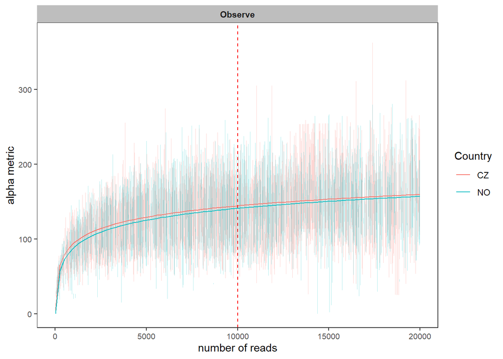

```r
prare
```

**Library size**

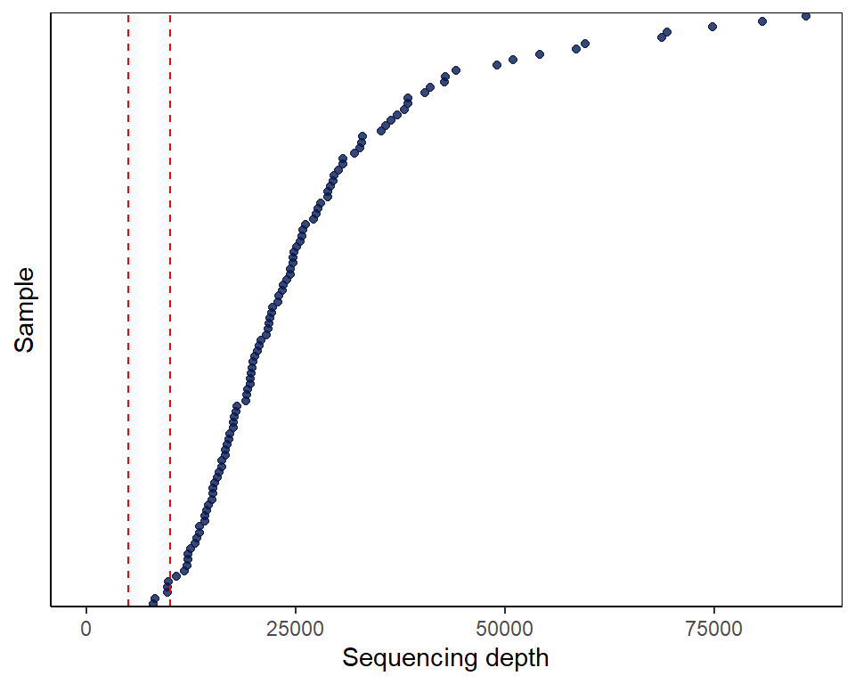

```r
read_counts(ileum_asv_tab, line = c(5000,10000))
```

### 2.1.1 Sequencing depth

```r
data_filt <- seq_depth_filtering(ileum_asv_tab,
                                 ileum_taxa_tab,
                                 ileum_metadata,
                                 seq_depth_threshold = 10000)
```

```
Removing 82 ASV(s)
```

```r
filt_ileum_asv_tab <- data_filt[[1]]; alpha_ileum_asv_tab <- filt_ileum_asv_tab
filt_ileum_taxa_tab <- data_filt[[2]]; alpha_ileum_taxa_tab <- filt_ileum_taxa_tab
filt_ileum_metadata <- data_filt[[3]]; alpha_ileum_metadata <- filt_ileum_metadata

seq_step <- dim(filt_ileum_asv_tab)[1]
```

**Library size**

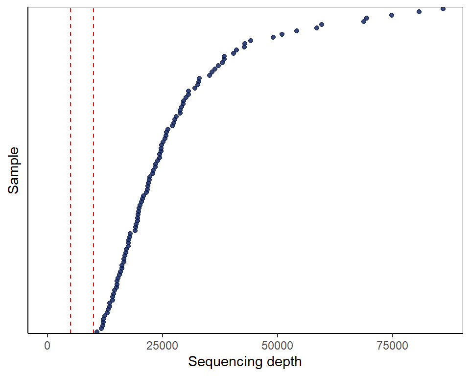

```r
read_counts(filt_ileum_asv_tab,line = c(5000,10000))
```

### 2.1.2 NearZeroVar

```r
data_filt <- nearzerovar_filtering(filt_ileum_asv_tab,
                                   filt_ileum_taxa_tab,
                                   filt_ileum_metadata)

filt_ileum_asv_tab <- data_filt[[1]]
filt_ileum_taxa_tab <- data_filt[[2]]
nearzero_step <- dim(filt_ileum_asv_tab)[1]
```

Library size

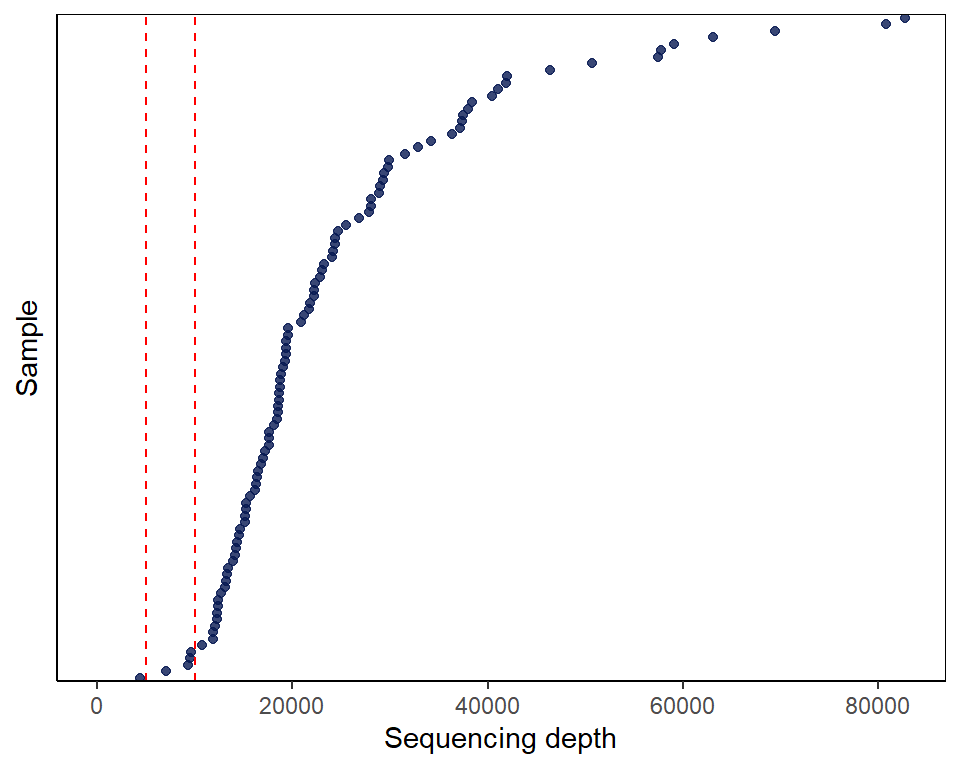

```r
read_counts(filt_ileum_asv_tab,line = c(5000,10000))
```

### 2.1.3 Final Counts

```r
final_counts_filtering(ileum_asv_tab,
                       filt_ileum_asv_tab,
                       filt_ileum_metadata,
                       seq_step, 0, nearzero_step) %>% `colnames<-`("Count")
```

```
                            Count
Raw data: ASVs               2836
Raw data: Samples             108
Sequencing depth filt: ASVs  2754
Prevalence filt: ASVs           0
NearZeroVar filt: ASVs        994
Filt data: ASVs               994
Filt data: Samples            103
Filt data: Patients           103
Filt data: Patients.1           0
Filtered samples                5
Matrices                       TI
healthy                         0
non-rPSC                        0
rPSC                            0
pre_ltx                         0
post_ltx                        0
ETOH                            0
```

## 2.2 Alpha diversity

```r
path = "../../../results/merged_sites/main_analysis/Q3/alpha_diversity"
```

**Calculation**

```r
# Construct MPSE object
alpha_ileum_metadata$Sample <- alpha_ileum_metadata$SampleID
ileum_mpse <- as.MPSE(construct_phyloseq(alpha_ileum_asv_tab,
                                         alpha_ileum_taxa_tab,
                                         alpha_ileum_metadata))

ileum_mpse %<>% mp_rrarefy(raresize = 10000,seed = 123)

# Calculate alpha diversity - rarefied counts
ileum_mpse %<>% mp_cal_alpha(.abundance=RareAbundance, force=TRUE)
```

```r
alpha_div_plots <- list()

# preparing data frame
alpha_data <- data.frame(SampleID=ileum_mpse$Sample.x,
                         Observe=ileum_mpse$Observe,
                         Shannon=ileum_mpse$Shannon,
                         Simpson=ileum_mpse$Simpson,
                         Pielou=ileum_mpse$Pielou,
                         Group=ileum_mpse$Group,
                         Country=ileum_mpse$Country,
                         Patient=ileum_mpse$Patient)

write.csv(alpha_data,file.path(path,paste0("alpha_indices_",segment,".csv")),
          row.names = FALSE)
```

```r
alpha_data <- read.csv(file.path(path,paste0("alpha_indices_",segment,".csv")))
```

### 2.2.1 Plots

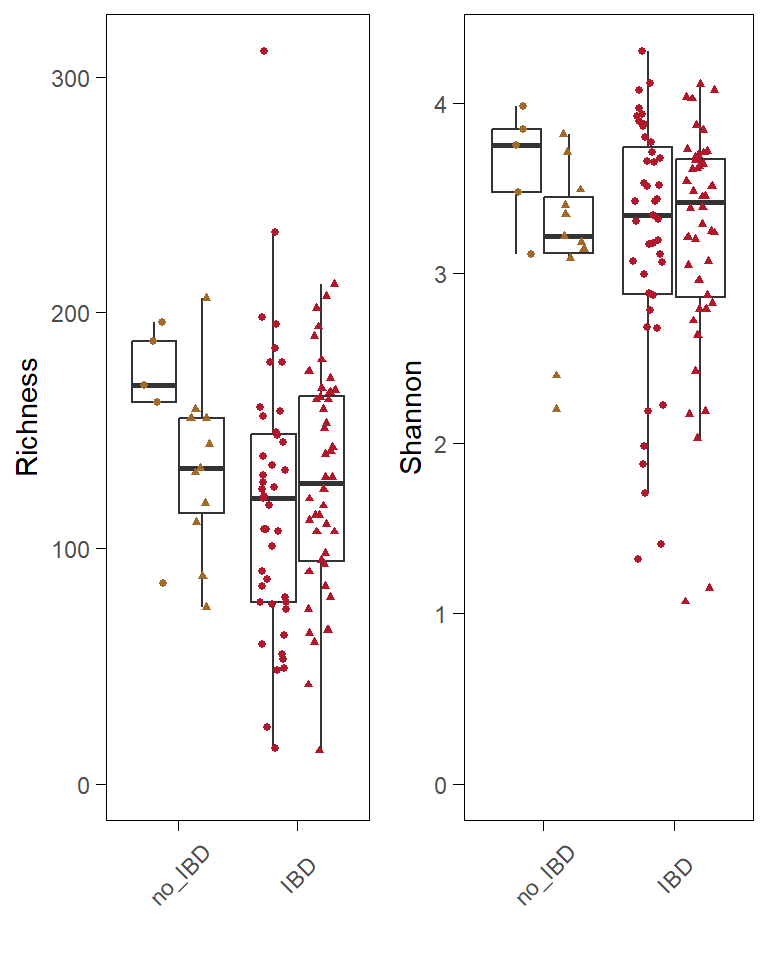

```r
p_boxplot_alpha <- alpha_diversity_countries(alpha_data,
                                             show_legend = FALSE,
                                             size=1,gap=FALSE)
# save the results
alpha_div_plots[[paste(segment,"Country")]] <- p_boxplot_alpha

# see the results
p_boxplot_alpha
```

### 2.2.2 Linear Model

```r
path = "../../../results/merged_sites/main_analysis/Q3/alpha_diversity"
alpha_data <- read.csv(file.path(path,paste0("alpha_indices_",segment,".csv")))
```

**Richness**

```r
results_model <- pairwise.lm(formula = "Observe ~ Group * Country",
                             factors=alpha_data$Group,
                             data=alpha_data)

# check interaction
if (!is.data.frame(results_model)){
  results_model_observe <- results_model[[1]]
  results_model_observe_emeans <- results_model[[2]]
} else {
  results_model_observe <- results_model
  results_model_observe_emeans <- NA
}

# save the results
pc_observed <- list();
pc_observed[[segment]] <- results_model_observe
```

```r
# see the results
knitr::kable(results_model_observe,digits = 3,
caption = "Raw results of linear model of richness estimation.")
```

Raw results of linear model of richness estimation.

|  | Estimate | Std. Error | t value | Pr(>\|t\|) |
| --- | --- | --- | --- | --- |
| no_ibd vs Groupibd | -41.186 | 24.041 | -1.713 | 0.090 |
| no_ibd , ibd - CZ vs NO | -25.636 | 27.443 | -0.934 | 0.352 |
| no_ibd vs Groupibd:CountryNO | 34.572 | 29.532 | 1.171 | 0.245 |

```r
knitr::kable(results_model_observe_emeans,digits = 3,
caption = "Raw results of independent country analysis")
```

Table: Raw results of independent country analysis

**Shannon**

```r
results_model <- pairwise.lm(formula = "Shannon ~ Group * Country",
                             factors=alpha_data$Group,
                             data=alpha_data)

# check interaction
if (!is.data.frame(results_model)){
  results_model_shannon <- results_model[[1]]
  results_model_shannon_emeans <- results_model[[2]]
} else {
  results_model_shannon <- results_model
  results_model_shannon_emeans <- NA
}

# save the results
pc_shannon <- list();
pc_shannon[[segment]] <- as.data.frame(results_model_shannon)
```

```r
# see the results
knitr::kable(results_model_shannon,digits = 3,
caption = "Raw results of linear model of Shannon estimation.")
```

Raw results of linear model of Shannon estimation.

|  | Estimate | Std. Error | t value | Pr(>\|t\|) |
| --- | --- | --- | --- | --- |
| no_ibd vs Groupibd | -0.438 | 0.325 | -1.349 | 0.180 |
| no_ibd , ibd - CZ vs NO | -0.453 | 0.371 | -1.221 | 0.225 |
| no_ibd vs Groupibd:CountryNO | 0.471 | 0.399 | 1.180 | 0.241 |

```r
knitr::kable(results_model_shannon_emeans,digits = 3,
caption = "Raw results of independent country analysis")
```

Table: Raw results of independent country analysis

**Simpson**

```r
results_model <- pairwise.lm(formula = "Simpson ~ Group * Country",
                                     factors=alpha_data$Group,
                                     data=alpha_data)

# check interaction
if (!is.data.frame(results_model)){
  results_model_simpson <- results_model[[1]]
  results_model_simpson_emeans <- results_model[[2]]
} else {
  results_model_simpson <- results_model
  results_model_simpson_emeans <- NA
}


# save the results
pc_simpson <- list();
pc_simpson[[segment]] <- as.data.frame(results_model_simpson)
```

```r
# see the results
knitr::kable(results_model_simpson,digits = 3,
caption = "Raw results of linear model of Simpson estimation.")
```

Raw results of linear model of Simpson estimation.

|  | Estimate | Std. Error | t value | Pr(>\|t\|) |
| --- | --- | --- | --- | --- |
| no_ibd vs Groupibd | -0.043 | 0.043 | -1.004 | 0.318 |
| no_ibd , ibd - CZ vs NO | -0.047 | 0.049 | -0.974 | 0.332 |
| no_ibd vs Groupibd:CountryNO | 0.045 | 0.052 | 0.865 | 0.389 |

```r
knitr::kable(results_model_simpson_emeans,digits = 3,
caption = "Raw results of independent country analysis")
```

Table: Raw results of independent country analysis

**Pielou**

```r
results_model <- pairwise.lm(formula = "Pielou ~ Group * Country",
                                     factors=alpha_data$Group,
                                     data=alpha_data)

# check interaction

if (!is.data.frame(results_model)){
  results_model_pielou <- results_model[[1]]
  results_model_pielou_emeans <- results_model[[2]]
} else {
  results_model_pielou <- results_model
  results_model_pielou_emeans <- NA
}

# save the results
pc_pielou <- list();
pc_pielou[[segment]] <- as.data.frame(results_model_pielou)
```

```r
# see the results
knitr::kable(results_model_pielou,digits = 3,
caption = "Raw results of linear model of Pielou estimation.")
```

Raw results of linear model of Pielou estimation.

|  | Estimate | Std. Error | t value | Pr(>\|t\|) |
| --- | --- | --- | --- | --- |
| no_ibd vs Groupibd | -0.042 | 0.046 | -0.910 | 0.365 |
| no_ibd , ibd - CZ vs NO | -0.068 | 0.052 | -1.305 | 0.195 |
| no_ibd vs Groupibd:CountryNO | 0.056 | 0.056 | 1.007 | 0.317 |

```r
knitr::kable(results_model_pielou_emeans,digits = 3,
caption = "Raw results of independent country analysis")
```

Table: Raw results of independent country analysis

### 2.2.3 Saving results

```r
alpha_list <- list(
  Richness=pc_observed[[segment]],
  Shannon=pc_shannon[[segment]])

write.xlsx(alpha_list,
           file = file.path(path,paste0("alpha_diversity_results_",segment,".xlsx")))
```

## 2.3 Beta diversity

### 2.3.1 Main analysis

**Genus level, Aitchison distance**

```r
level="genus"
```

```r
path = "../../../results/merged_sites/main_analysis/Q3/beta_diversity"
```

```r
pairwise_aitchison_raw <- list()
pca_plots_list <- list()
```

Aggregation, filtering

```r
# Aggregation
genus_data <- aggregate_taxa(ileum_asv_tab,
                             ileum_taxa_tab,
                             taxonomic_level=level,
                             names=TRUE)
# Filtration
filt_data <- filtering_steps(genus_data[[1]],
                             genus_data[[2]],
                             ileum_metadata,
                             seq_depth_threshold=10000)
```

```
Removing 6 ASV(s)
```

```r
filt_ileum_genus_tab <- filt_data[[1]]
filt_ileum_genus_taxa <- filt_data[[2]]
filt_ileum_metadata <- filt_data[[3]]
```

##### 2.3.1.0.1 PERMANOVA

```r
pairwise_df <- filt_ileum_genus_tab %>% column_to_rownames("SeqID") %>% t()

# main effect
pp_main <- pairwise.adonis(pairwise_df,
                           filt_ileum_metadata$Group,
                           covariate = filt_ileum_metadata$Country, sim.method = "robust.aitchison", p.adjust.m="BH")

# interaction
pp_int <- pairwise.adonis(pairwise_df,filt_ileum_metadata$Group,covariate = filt_ileum_metadata$Country, interaction = TRUE, sim.method = "robust.aitchison", p.adjust.m="BH")

# tidy the results
pp_factor <- pp_main[[1]]
pp_cov <- pp_main[[2]]
pp_fac.cov <- pp_int[[3]]

cols <- c("pairs","Df","SumsOfSqs", "F.Model","R2","p.value", "p.adjusted", "sig")
colnames(pp_factor) <- cols; colnames(pp_cov) <- cols; colnames(pp_fac.cov) <- cols;

# save raw results
pairwise_aitchison_raw[[paste(level, segment)]] <- rbind(pp_factor,pp_cov,pp_fac.cov)
```

```r
# see the results
knitr::kable(pp_factor,digits = 3,caption = "PERMANOVA, GROUP separation")
```

PERMANOVA, GROUP separation

| pairs | Df | SumsOfSqs | F.Model | R2 | p.value | p.adjusted | sig |
| --- | --- | --- | --- | --- | --- | --- | --- |
| no_ibd vs ibd | 1 | 204.897 | 1.148 | 0.011 | 0.175 | 0.175 |  |

```r
knitr::kable(pp_cov,digits = 3,caption = "PERMANOVA, COUNTRY separation")
```

PERMANOVA, COUNTRY separation

| pairs | Df | SumsOfSqs | F.Model | R2 | p.value | p.adjusted | sig |
| --- | --- | --- | --- | --- | --- | --- | --- |
| no_ibd vs ibd , Country | 1 | 562.985 | 3.155 | 0.03 | 0.001 | 0.001 | *** |

```r
knitr::kable(pp_fac.cov,digits = 3,caption = "PERMANOVA, INTERACTION GROUP:Country")
```

PERMANOVA, INTERACTION GROUP:Country

| pairs | Df | SumsOfSqs | F.Model | R2 | p.value | p.adjusted | sig |
| --- | --- | --- | --- | --- | --- | --- | --- |
| no_ibd vs ibd : Country | 1 | 168.942 | 0.946 | 0.009 | 0.564 | 0.564 |  |

Interaction check

```r
interaction_sig <- pp_fac.cov$pairs[pp_fac.cov$p.adjusted < 0.1]

if (length(interaction_sig)>0){
  for (i in 1:length(interaction_sig)){
  group1 <- unlist(strsplit(interaction_sig[i],split = " vs "))[1]
  group2 <- unlist(strsplit(interaction_sig[i],split = " vs "))[2]
  group2 <- unlist(strsplit(group2,split = " : "))[1]

  result_list <- adonis_postanalysis(x=pairwise_df,
                      factors = filt_ileum_metadata$Group,
                      covariate = filt_ileum_metadata$Country,
                      group1 = group1,
                      group2 = group2)
  print(result_list)
}
}
```

##### 2.3.1.0.2 Plots

**PCA**

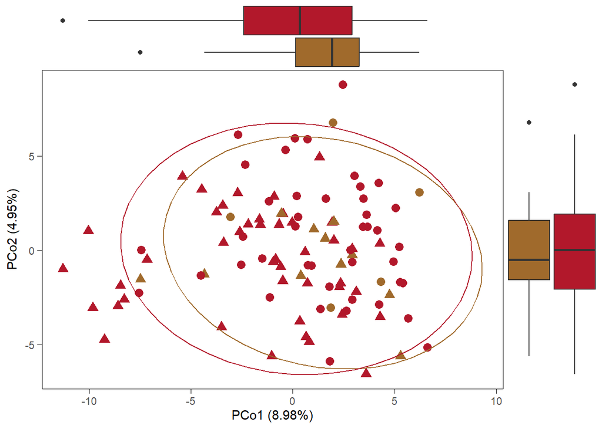

```r
p <- pca_plot_custom(filt_ileum_genus_tab,
                                 filt_ileum_genus_taxa,
                                 filt_ileum_metadata,
                                 show_boxplots = TRUE,
                                 variable = "Group", size=3, show_legend=FALSE)

# save the results
pca_plots_list[[paste(segment,level,"custom")]] <- p

# see the results
p
```

#### 2.3.1.1 Saving results

```r
write.xlsx(pairwise_aitchison_raw[[paste(level, segment)]],
           file = file.path(path,
           paste0("beta_diversity_results_", segment,".xlsx")))
```

## 2.4 Univariate Analysis

### 2.4.1 Main analysis

```r
level="genus"
```

```r
# needed paths
path = "../../../results/merged_sites/main_analysis/Q3/univariate_analysis"
path_maaslin=file.path("../../../intermediate_files/maaslin/Q3",level)
```

```r
# variables
raw_linda_results_genus <- list();
raw_linda_results_genus[[segment]] <- list()
linda_results_genus <- list();
linda_results_genus[[segment]] <- list()

# country and interaction problems
list_intersections <- list()
list_venns <- list()
uni_statistics <- list()

# workbook for final df
wb <- createWorkbook()

# PSC effect
psc_effect <- list()
```

Aggregate taxa

```r
genus_data <- aggregate_taxa(ileum_asv_tab,
                             ileum_taxa_tab,
                             taxonomic_level = level)

ileum_genus_tab <- genus_data[[1]]
ileum_genus_taxa_tab <- genus_data[[2]]

ileum_genus_asv_taxa_tab <- create_asv_taxa_table(ileum_genus_tab,
                                                  ileum_genus_taxa_tab)
```

#### 2.4.1.1 ibd vs no_ibd

```r
group <- c("no_ibd","ibd")
comparison_name <- paste0(group[1], " vs ",group[2])
```

##### 2.4.1.1.1 linDA

```r
# prepare the data
linda_data <- binomial_prep(ileum_genus_tab,
                            ileum_genus_taxa_tab,
                            ileum_metadata,
                            group, usage="linDA")
```

```
Removing 6 ASV(s)
```

```r
filt_ileum_uni_data <- linda_data[[1]]
filt_ileum_uni_taxa <- linda_data[[2]]
filt_ileum_uni_metadata <- linda_data[[3]]

# fit the model
linda.obj <- linda(filt_ileum_uni_data,
                   filt_ileum_uni_metadata,
                   formula = '~ Group * Country')
```

```
0  features are filtered!
The filtered data has  103  samples and  236  features will be tested!
```

```
Imputation approach is used.
Fit linear models ...
Completed.
```

```r
linda.output <- linda.obj$output
linda.output <- linda_renaming(linda.output, group)

# save the results
group1 <- paste0(group[1], " vs ","Group",group[2])
group2 <- paste0(group[1], " , ",group[2], " - CZ vs NO")
group3 <- paste0(group[1], " vs ","Group",group[2], ":CountryNO")

for (grp in c(group1,group2,group3)){
  raw_linda_results_genus[[segment]][[grp]] <-
    rawlinda.df(linda.output,
                grp,
                filt_ileum_uni_data,
                filt_ileum_uni_taxa)

  linda_results_genus[[segment]][[grp]] <-
    linda.df(linda.output,
             grp,
             filt_ileum_uni_data,
             filt_ileum_uni_taxa)
}
```

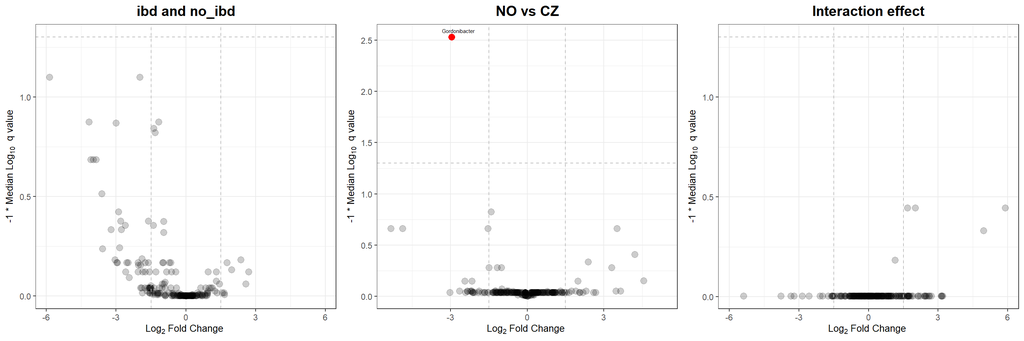

```r
# volcano plot
volcano_1 <- volcano_plot_linda(linda.output,
                                group1,
                                taxa_table = filt_ileum_uni_taxa) +
            ggtitle(comparison_title)

volcano_2  <- volcano_plot_linda(linda.output, group2,
                                taxa_table = filt_ileum_uni_taxa) +
            ggtitle("NO vs CZ")

volcano_3 <- volcano_plot_linda(linda.output, group3,
                                taxa_table = filt_ileum_uni_taxa) +
            ggtitle("Interaction effect")

volcano <- ggarrange(volcano_1,volcano_2,volcano_3, ncol=3)
volcano
```

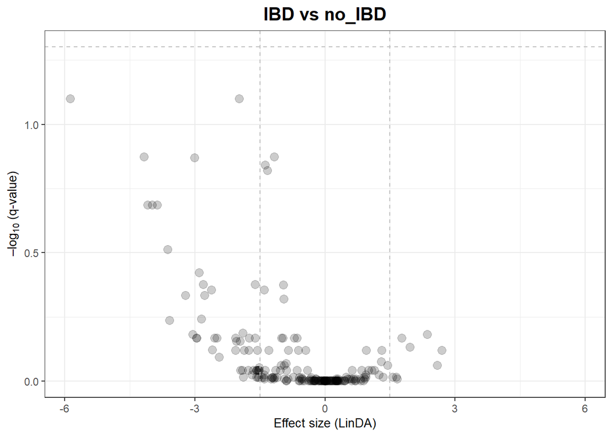

```r
volcano_linda_ileum <- volcano_1 +
  ggtitle("IBD vs no_IBD") +
  xlab("Effect size (LinDA)") +
  ylab("–log"[10]~"(q-value)")

volcano_linda_ileum
```

##### 2.4.1.1.2 MaAsLin2

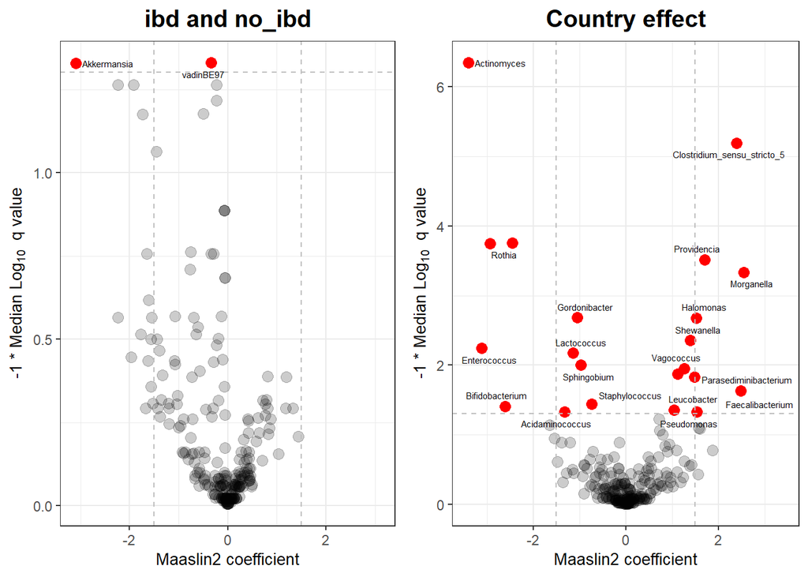

```r
volcano1 <- volcano_plot_maaslin(fit_data,filt_ileum_uni_taxa) +
            ggtitle(comparison_title)

volcano2 <- volcano_plot_maaslin(fit_data,filt_ileum_uni_taxa,variable="Country") +
            ggtitle("Country effect")

volcano <- ggarrange(volcano1,volcano2, ncol=2)
volcano
```

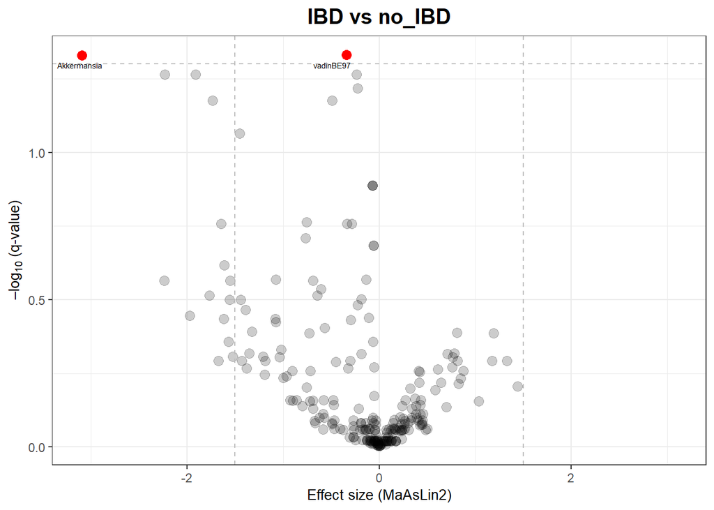

```r
volcano_maaslin_ileum <- volcano1 +
  ggtitle("IBD vs no_IBD") +
  xlab("Effect size (MaAsLin2)") +
  ylab("–log"[10]~"(q-value)")

volcano_maaslin_ileum
```

##### 2.4.1.1.3 Group - Intersection

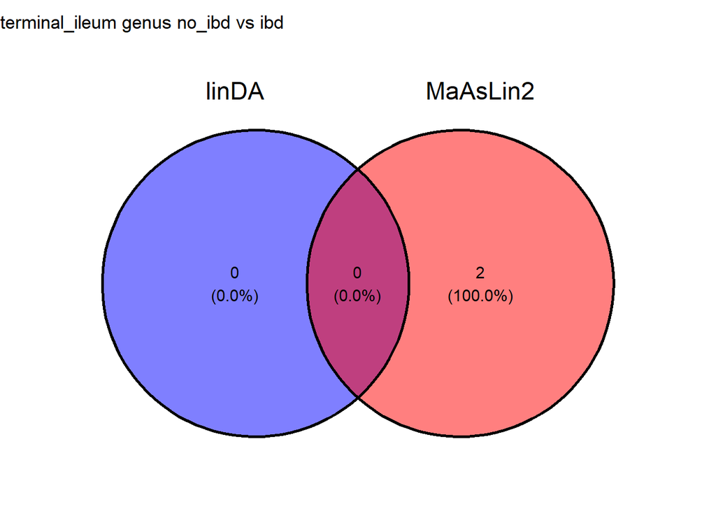

```r
intersection_results <- group_intersection(group, list_intersections, list_venns,
                                           linda.output, fit_data,
                                           raw_linda_results_genus,
                                           segment = segment,
                                           level=level)

list_intersections <- intersection_results[[1]]
list_venns <- intersection_results[[2]]
venn <- intersection_results[[3]]

# show the results
venn
```

##### 2.4.1.1.4 Interaction effect

```r
list_interaction_significant <- country_interaction(group,
                                                    linda.output,
                                                    list_intersections,
                                          filt_ileum_uni_data,
                                          filt_ileum_uni_metadata,
                                          segment=segment,
                                          level=level)

# see the result
## significant interaction effect
list_interaction_significant[[1]]
```

```r
## results for czech cohort
list_interaction_significant[[2]]
```

```
[1] NA
```

```r
## results for norwegian cohort
list_interaction_significant[[3]]
```

```
[1] NA
```

Removing problematic taxa

```r
list_intersections <- removing_interaction_problems(group,
                                                    list_interaction_significant,
                                                    list_intersections,
                                                    segment=segment,
                                                    level=level)
```

##### 2.4.1.1.5 Basic statistics

```r
uni_df <-  merge(basic_univariate_statistics(linda_data,group),
                 raw_linda_results_genus[[segment]][[group1]],
                 by="SeqID",all=TRUE)
```

```
[1] "no_ibd"
[1] "ibd"
[1] "no_ibd"
[1] "ibd"
```

```r
uni_df[["final_sig"]] <- uni_df$SeqID %in% list_intersections[[paste(segment,level,comparison_name)]][["SeqID"]]
uni_statistics[[segment]][[paste(level,comparison_name)]] <- uni_df

# for comparison
new_name <- comparison_name
addWorksheet(wb, sheetName = new_name)
writeData(wb, sheet = new_name, uni_df, rowNames=FALSE)
```

#### 2.4.1.2 Visualization

Heatmap visualizing the linDA’s logFoldChange for taxa with p < 0.1.

```r
list_heatmap <- list_intersections[grep(paste(segment,level),
                                  names(list_intersections),value=TRUE)]

if (length((list_heatmap[[1]][[1]]))>1){
  p_heatmap_linda <- heatmap_linda(list_heatmap,ileum_taxa_tab)
  p_heatmap_linda
}
```

Dotheatmap

```r
if (length((list_heatmap[[1]][[1]]))>0){
dotheatmap_linda <- dot_heatmap_linda(list_heatmap,
                                      uni_statistics$terminal_ileum[grepl(level,names(uni_statistics$terminal_ileum))],
                                      ileum_taxa_tab)
dotheatmap_linda

}
```

**Horizontal bar plot**

```r
if (length((list_heatmap[[1]][[1]]))>0){
p_prevalence <- horizontal_barplot(wb,taxa=levels(dotheatmap_linda$data$SeqID))

p_prevalence_final <- ggarrange(p_prevalence,
                                ggplot() + theme_minimal(),
                                nrow = 2,heights = c(1,0.085))
p <- ggarrange(dotheatmap_linda + theme(legend.position = "none"),p_prevalence_final,ncol=2,widths = c(1,0.2))
p
}
```

#### 2.4.1.3 Saving results

```r
# ALL DATA
saveWorkbook(wb,file.path(path,paste0("uni_analysis_wb_",segment,".xlsx")),
             overwrite = TRUE)

# PSC effect
write.xlsx(psc_effect[[paste(segment,level)]],file.path(path,paste0("psc_effect_",segment,".xlsx")))

# SIGNIFICANT taxa

write.xlsx(list_intersections[grepl(segment,names(list_intersections))] %>%
            `names<-`(gsub(segment, "", names(
              list_intersections[grepl(segment,names(list_intersections))]))),
           file.path(path,paste0("significant_taxa_",segment,".xlsx")))
```

## 2.5 Results overview

#### 2.5.0.1 Alpha diversity

```r
knitr::kable(pc_observed[[segment]],
             digits = 3,
             caption = "Results of linear model testing ASV Richness")
```

Results of linear model testing ASV Richness

|  | Estimate | Std. Error | t value | Pr(>\|t\|) |
| --- | --- | --- | --- | --- |
| no_ibd vs Groupibd | -41.186 | 24.041 | -1.713 | 0.090 |
| no_ibd , ibd - CZ vs NO | -25.636 | 27.443 | -0.934 | 0.352 |
| no_ibd vs Groupibd:CountryNO | 34.572 | 29.532 | 1.171 | 0.245 |

```r
knitr::kable(pc_shannon[[segment]],
             digits = 3,
             caption = "Results of linear model testing Shannon index")
```

Results of linear model testing Shannon index

|  | Estimate | Std. Error | t value | Pr(>\|t\|) |
| --- | --- | --- | --- | --- |
| no_ibd vs Groupibd | -0.438 | 0.325 | -1.349 | 0.180 |
| no_ibd , ibd - CZ vs NO | -0.453 | 0.371 | -1.221 | 0.225 |
| no_ibd vs Groupibd:CountryNO | 0.471 | 0.399 | 1.180 | 0.241 |

```r
knitr::kable(pc_simpson[[segment]],
             digits = 3,
             caption = "Results of linear model testing Simpson index")
```

Results of linear model testing Simpson index

|  | Estimate | Std. Error | t value | Pr(>\|t\|) |
| --- | --- | --- | --- | --- |
| no_ibd vs Groupibd | -0.043 | 0.043 | -1.004 | 0.318 |
| no_ibd , ibd - CZ vs NO | -0.047 | 0.049 | -0.974 | 0.332 |
| no_ibd vs Groupibd:CountryNO | 0.045 | 0.052 | 0.865 | 0.389 |

```r
knitr::kable(pc_pielou[[segment]],
             digits = 3,
             caption = "Results of linear model testing Pielou index")
```

Results of linear model testing Pielou index

|  | Estimate | Std. Error | t value | Pr(>\|t\|) |
| --- | --- | --- | --- | --- |
| no_ibd vs Groupibd | -0.042 | 0.046 | -0.910 | 0.365 |
| no_ibd , ibd - CZ vs NO | -0.068 | 0.052 | -1.305 | 0.195 |
| no_ibd vs Groupibd:CountryNO | 0.056 | 0.056 | 1.007 | 0.317 |

Plots

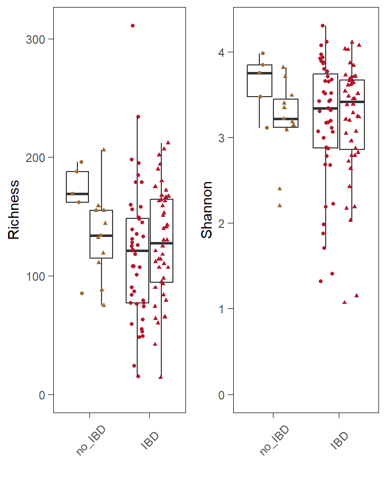

```r
alpha_div_plots[[paste(segment,"Country")]]
```

#### 2.5.0.2 Beta diversity

**Main results**

```r
knitr::kable(pairwise_aitchison_raw[[paste("genus", segment)]],
             digits = 3,
             caption = "Results of PERMANOVA - robust aitchison distance")
```

Results of PERMANOVA - robust aitchison distance

| pairs | Df | SumsOfSqs | F.Model | R2 | p.value | p.adjusted | sig |
| --- | --- | --- | --- | --- | --- | --- | --- |
| no_ibd vs ibd | 1 | 204.897 | 1.148 | 0.011 | 0.175 | 0.175 |  |
| no_ibd vs ibd , Country | 1 | 562.985 | 3.155 | 0.030 | 0.001 | 0.001 | *** |
| no_ibd vs ibd : Country | 1 | 168.942 | 0.946 | 0.009 | 0.564 | 0.564 |  |

*PCA*

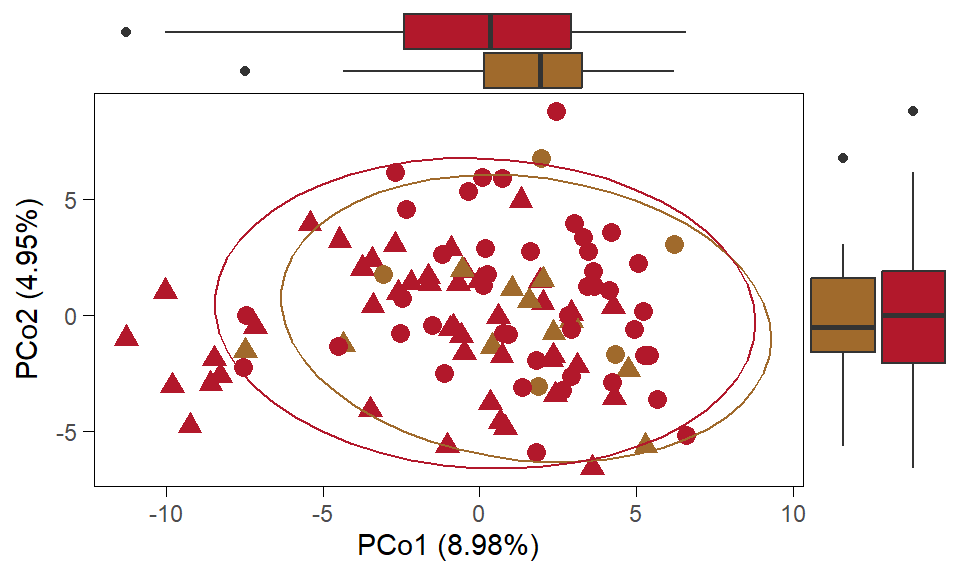

```r
pca_plots_list[[paste(segment,"genus custom")]]
```

#### 2.5.0.3 Univariate analysis

**Number of significant taxa**

```r
knitr::kable(as.data.frame(lapply(list_intersections,nrow)) %>% t() %>%
  `colnames<-`("Count") %>%
  `rownames<-`(c(names(list_intersections))),caption="Number of significant taxa")
```

Number of significant taxa

|  | Count |
| --- | --- |
| terminal_ileum genus no_ibd vs ibd | 0 |

# 3 Data Analysis - Colon

```r
segment="colon"
```

## 3.1 Filtering

Library size

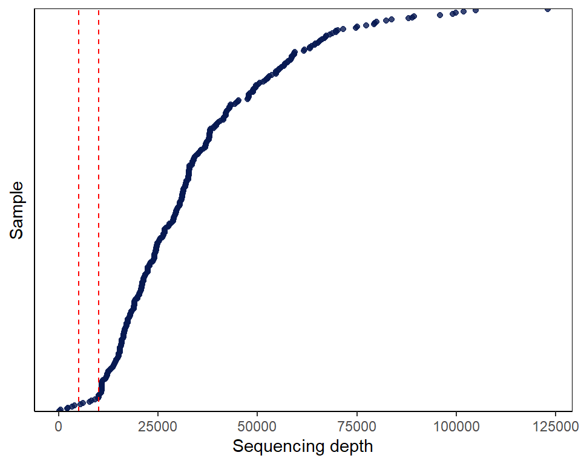

```r
read_counts(colon_asv_tab, line = c(5000,10000))
```

### 3.1.1 Sequencing depth

```r
data_filt <- seq_depth_filtering(colon_asv_tab,
                                 colon_taxa_tab,
                                 colon_metadata,
                                 seq_depth_threshold = 10000)
```

```
Removing 43 ASV(s)
```

```r
filt_colon_asv_tab <- data_filt[[1]]; alpha_colon_asv_tab <- filt_colon_asv_tab
filt_colon_taxa_tab <- data_filt[[2]]; alpha_colon_taxa_tab <- filt_colon_taxa_tab
filt_colon_metadata <- data_filt[[3]]; alpha_colon_metadata <- filt_colon_metadata

seq_step <- dim(filt_colon_asv_tab)[1]
```

Library size

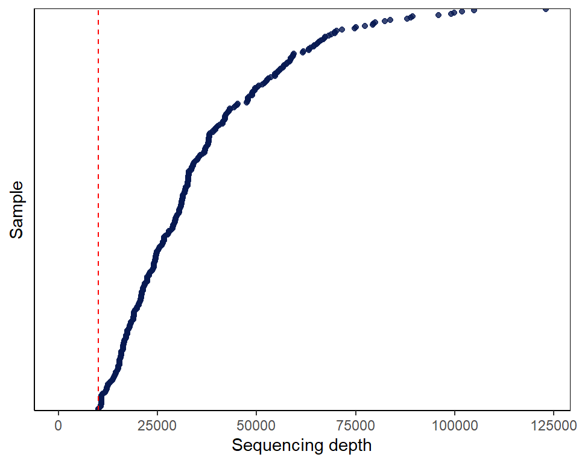

```r
read_counts(filt_colon_asv_tab,line = c(10000))
```

### 3.1.2 NearZeroVar

```r
data_filt <- nearzerovar_filtering(filt_colon_asv_tab,
                                   filt_colon_taxa_tab,
                                   filt_colon_metadata)

filt_colon_asv_tab <- data_filt[[1]]
filt_colon_taxa_tab <- data_filt[[2]]
nearzero_step <- dim(filt_colon_asv_tab)[1]
```

Library size

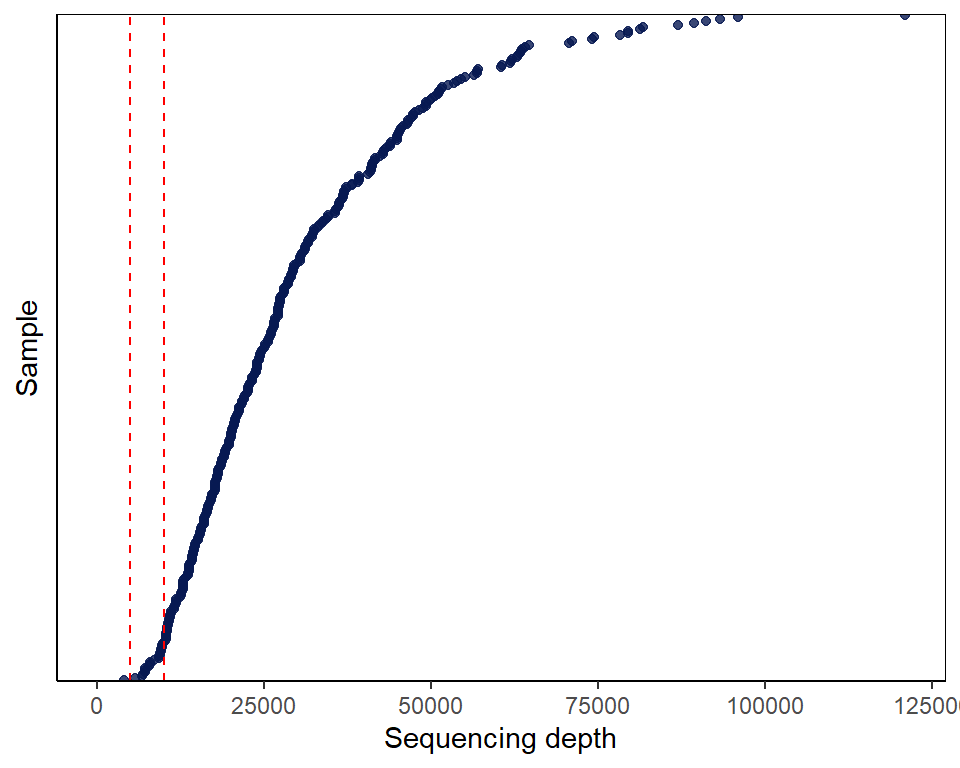

```r
read_counts(filt_colon_asv_tab,line = c(5000,10000))
```

Check zero depth

```r
data_filt <- check_zero_depth(filt_colon_asv_tab,
                              filt_colon_taxa_tab,
                              filt_colon_metadata)

filt_colon_asv_tab <- data_filt[[1]];
filt_colon_taxa_tab <- data_filt[[2]];
filt_colon_metadata <- data_filt[[3]];
```

Library size

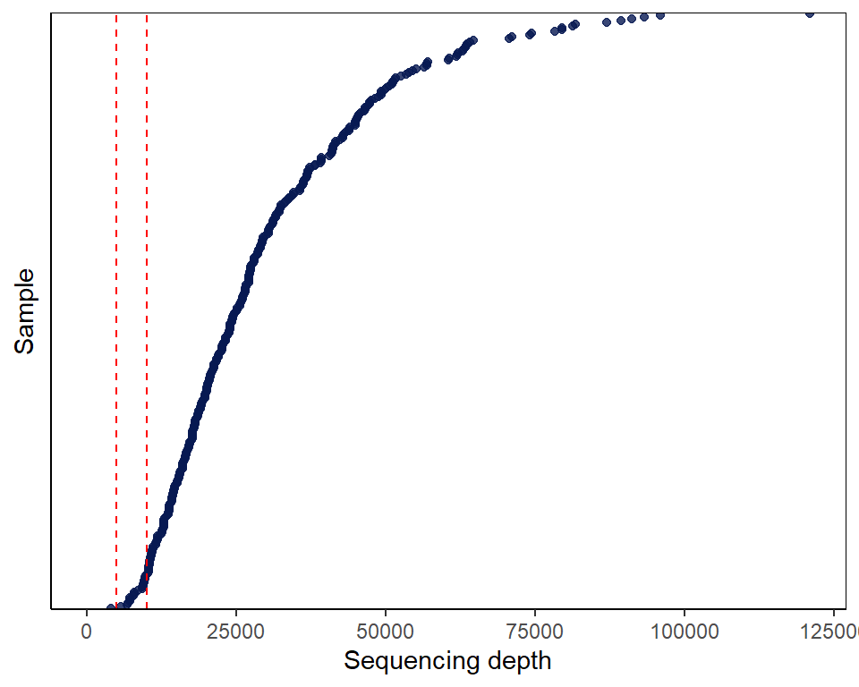

```r
read_counts(filt_colon_asv_tab,line = c(5000,10000))
```

### 3.1.3 Final Counts

```r
final_counts_filtering(colon_asv_tab,
                       filt_colon_asv_tab,
                       filt_colon_metadata,
                       seq_step, 0, nearzero_step)
```

```
                                               V1
Raw data: ASVs                               4084
Raw data: Samples                             350
Sequencing depth filt: ASVs                  4041
Prevalence filt: ASVs                           0
NearZeroVar filt: ASVs                        354
Filt data: ASVs                               354
Filt data: Samples                            337
Filt data: Patients                           143
Filt data: Patients.1                           0
Filtered samples                               13
Matrices                    CA;CD;SI;Cecum;Rectum
healthy                                         0
non-rPSC                                        0
rPSC                                            0
pre_ltx                                         0
post_ltx                                        0
ETOH                                            0
```

## 3.2 Alpha diversity

```r
path = "../../../results/merged_sites/main_analysis/Q3/alpha_diversity"
```

**Calculation**

```r
# Construct MPSE object
alpha_colon_metadata$Sample <- alpha_colon_metadata$SampleID
colon_mpse <- as.MPSE(construct_phyloseq(alpha_colon_asv_tab,
                                         alpha_colon_taxa_tab,
                                         alpha_colon_metadata))

colon_mpse %<>% mp_rrarefy(raresize = 10000,seed = 123)

# Calculate alpha diversity - rarefied counts
colon_mpse %<>% mp_cal_alpha(.abundance=RareAbundance, force=TRUE)
```

```r
alpha_data <- data.frame(SampleID=colon_mpse$Sample.x,
                         Observe=colon_mpse$Observe,
                         Shannon=colon_mpse$Shannon,
                         Simpson=colon_mpse$Simpson,
                         Pielou=colon_mpse$Pielou,
                         Group=colon_mpse$Group,
                         Country=colon_mpse$Country,
                         Patient=colon_mpse$Patient)

write.csv(alpha_data,file.path(path,paste0("alpha_indices_",segment,".csv")),
          row.names = FALSE)
```

### 3.2.1 Plots

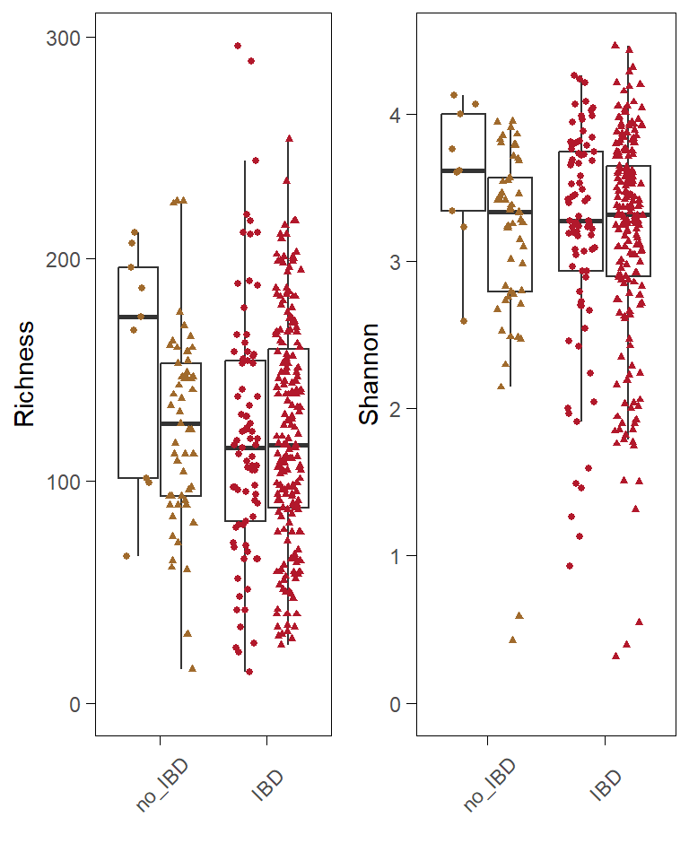

```r
p_boxplot_alpha <- alpha_diversity_countries(alpha_data,
                                             show_legend = FALSE,
                                             size=1,gap=FALSE)
# save the results
alpha_div_plots[[paste(segment,"Country")]] <- p_boxplot_alpha

# see the results
p_boxplot_alpha
```

### 3.2.2 Linear Model

```r
path = "../../../results/merged_sites/main_analysis/Q3/alpha_diversity"
alpha_data <- read.csv(file.path(path,paste0("alpha_indices_",segment,".csv")))
```

**Richness**

```r
results_model <- pairwise.lmer(
  formula = "Observe ~ Group * Country + (1|Patient)",
  factors=alpha_data$Group,
  data=alpha_data)

# check interaction
if (!is.data.frame(results_model)){
  results_model_observe <- results_model[[1]]
  results_model_observe_detailed <- results_model[[2]]
} else {
  results_model_observe <- results_model
  results_model_observe_detailed <- NA
}

# save the results
pc_observed[[segment]] <- results_model_observe
```

```r
# see the results
knitr::kable(results_model_observe,digits = 3,
caption = "Raw results of linear model of richness estimation.")
```

Raw results of linear model of richness estimation.

|  | Estimate | Std..Error | df | t.value | Pr…t.. | p.adj | sig |
| --- | --- | --- | --- | --- | --- | --- | --- |
| no_ibd vs Groupibd | 0.195 | 13.828 | 330.245 | 0.014 | 0.989 | 0.989 |  |
| no_ibd vs ibd - CZ vs NO | -0.556 | 18.199 | 238.733 | -0.031 | 0.976 | 0.976 |  |
| no_ibd vs Groupibd:CountryNO | -1.880 | 18.971 | 263.174 | -0.099 | 0.921 | 0.921 |  |

```r
knitr::kable(results_model_observe_detailed,digits = 3,
caption = "Raw results of independent country analysis")
```

Table: Raw results of independent country analysis

**Shannon**

```r
results_model <- pairwise.lmer(
  formula = "Shannon ~ Group * Country + (1|Patient)",
  factors=alpha_data$Group,
  data=alpha_data)

# check interaction
if (!is.data.frame(results_model)){
  results_model_shannon <- results_model[[1]]
  results_model_shannon_detailed <- results_model[[2]]
} else {
  results_model_shannon <- results_model
  results_model_shannon_detailed <- NA
}

# save the results
pc_shannon[[segment]] <- as.data.frame(results_model_shannon)
```

```r
# see the results
knitr::kable(results_model_shannon,digits = 3,
caption = "Raw results of linear model of Shannon estimation.")
```

Raw results of linear model of Shannon estimation.

|  | Estimate | Std..Error | df | t.value | Pr…t.. | p.adj | sig |
| --- | --- | --- | --- | --- | --- | --- | --- |
| no_ibd vs Groupibd | -0.038 | 0.204 | 332.621 | -0.185 | 0.854 | 0.854 |  |
| no_ibd vs ibd - CZ vs NO | -0.139 | 0.262 | 239.592 | -0.529 | 0.597 | 0.597 |  |
| no_ibd vs Groupibd:CountryNO | 0.101 | 0.275 | 262.547 | 0.367 | 0.714 | 0.714 |  |

```r
knitr::kable(results_model_shannon_detailed,digits = 3,
caption = "Raw results of independent country analysis")
```

Table: Raw results of independent country analysis

**Simpson**

```r
results_model <- pairwise.lmer(
  formula = "Simpson ~ Group * Country + (1|Patient)",
  factors=alpha_data$Group,
  data=alpha_data)

# check interaction
if (!is.data.frame(results_model)){
  results_model_simpson <- results_model[[1]]
  results_model_simpson_detailed <- results_model[[2]]
} else {
  results_model_simpson <- results_model
  results_model_simpson_detailed <- NA
}

# save the results
pc_simpson[[segment]] <- as.data.frame(results_model_simpson)
```

```r
# see the results
knitr::kable(results_model_simpson,digits = 3,
caption = "Raw results of linear model of Simpson estimation.")
```

Raw results of linear model of Simpson estimation.

|  | Estimate | Std..Error | df | t.value | Pr…t.. | p.adj | sig |
| --- | --- | --- | --- | --- | --- | --- | --- |
| no_ibd vs Groupibd | -0.015 | 0.033 | 332.974 | -0.447 | 0.656 | 0.656 |  |
| no_ibd vs ibd - CZ vs NO | -0.036 | 0.042 | 240.107 | -0.860 | 0.391 | 0.391 |  |
| no_ibd vs Groupibd:CountryNO | 0.035 | 0.044 | 261.852 | 0.797 | 0.426 | 0.426 |  |

```r
knitr::kable(results_model_simpson_detailed,digits = 3,
caption = "Raw results of independent country analysis")
```

Table: Raw results of independent country analysis

### 3.2.3 Saving results

```r
alpha_list <- list(
  Richness=pc_observed[[segment]] %>% rownames_to_column("Comparison"),
  Shannon=pc_shannon[[segment]] %>% rownames_to_column("Comparison"),
  Simpson=pc_simpson[[segment]] %>% rownames_to_column("Comparison"))

write.xlsx(alpha_list,
           file = file.path(path,paste0("alpha_diversity_results_",segment,".xlsx")))
```

## 3.3 Beta diversity

### 3.3.1 Main analysis - Genus, Aitchison

**Genus level, Aitchison distance**

```r
level="genus"
```

```r
path = "../../../results/merged_sites/main_analysis/Q3/beta_diversity"
```

Aggregation, filtering

```r
genus_data <- aggregate_taxa(colon_asv_tab,
                             colon_taxa_tab,
                             taxonomic_level=level,
                             names=TRUE)

filt_data <- filtering_steps(genus_data[[1]],
                             genus_data[[2]],
                             colon_metadata,
                            seq_depth_threshold=10000)
```

```
Removing 7 ASV(s)
```

```r
filt_colon_genus_tab <- filt_data[[1]]
filt_colon_genus_taxa <- filt_data[[2]]
filt_colon_genus_metadata <- filt_data[[3]]
```

##### 3.3.1.0.1 PERMANOVA

```r
pairwise_df <- filt_colon_genus_tab %>% column_to_rownames("SeqID") %>% t()

# main effect
pp_main <- pairwise.adonis(pairwise_df,filt_colon_genus_metadata$Group,
                           covariate = filt_colon_genus_metadata$Country,
                           patients = filt_colon_genus_metadata$Patient,
                           sim.method = "robust.aitchison", p.adjust.m="BH")

# interaction
pp_int <- pairwise.adonis(pairwise_df,filt_colon_genus_metadata$Group,
                          covariate = filt_colon_genus_metadata$Country,
                          interaction = TRUE,
                          patients = filt_colon_genus_metadata$Patient,
                          sim.method = "robust.aitchison", p.adjust.m="BH")

# tidy the results
pp_factor <- pp_main[[1]]
pp_cov <- pp_main[[2]]
pp_fac.cov <- pp_int[[3]]

cols <- c("pairs","Df","SumsOfSqs", "F.Model","R2","p.value", "p.adjusted", "sig")
colnames(pp_factor) <- cols; colnames(pp_cov) <- cols; colnames(pp_fac.cov) <- cols;

# save raw results
pairwise_aitchison_raw[[paste(level, segment)]] <-rbind(pp_factor,pp_cov,pp_fac.cov)
```

```r
# see the results
knitr::kable(pp_factor,digits = 3,caption = "PERMANOVA, GROUP separation")
```

PERMANOVA, GROUP separation

| pairs | Df | SumsOfSqs | F.Model | R2 | p.value | p.adjusted | sig |
| --- | --- | --- | --- | --- | --- | --- | --- |
| no_ibd vs ibd | 1 | 170.678 | 1.097 | 0.003 | 1 | 1 |  |

```r
knitr::kable(pp_cov,digits = 3,caption = "PERMANOVA, COUNTRY separation")
```

PERMANOVA, COUNTRY separation

| pairs | Df | SumsOfSqs | F.Model | R2 | p.value | p.adjusted | sig |
| --- | --- | --- | --- | --- | --- | --- | --- |
| no_ibd vs ibd , Country | 1 | 396.369 | 2.547 | 0.008 | 0.169 | 0.169 |  |

```r
knitr::kable(pp_fac.cov,digits = 3,caption = "PERMANOVA, INTERACTION GROUP:Country")
```

PERMANOVA, INTERACTION GROUP:Country

| pairs | Df | SumsOfSqs | F.Model | R2 | p.value | p.adjusted | sig |
| --- | --- | --- | --- | --- | --- | --- | --- |
| no_ibd vs ibd : Country | 1 | 133.144 | 0.855 | 0.003 | 0.999 | 0.999 |  |

Interaction check

```r
interaction_sig <- pp_fac.cov$pairs[pp_fac.cov$p.adjusted < 0.1]

if (length(interaction_sig)>0){
 for (i in 1:length(interaction_sig)){
  group1 <- unlist(strsplit(interaction_sig[i],split = " vs "))[1]
  group2 <- unlist(strsplit(interaction_sig[i],split = " vs "))[2]
  group2 <- unlist(strsplit(group2,split = " : "))[1]

  result_list <- adonis_postanalysis(x=pairwise_df,
                      factors = filt_colon_genus_metadata$Group,
                      covariate = filt_colon_genus_metadata$Country,
                      group1 = group1,
                      group2 = group2,
                      patients = filt_colon_genus_metadata$Patient)
  print(result_list)
}
}
```

##### 3.3.1.0.2 Plots

**PCoA custom**

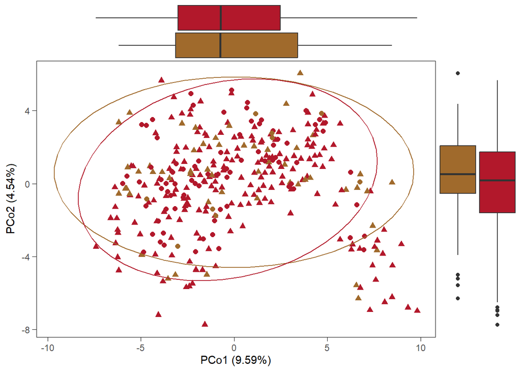

```r
p <- pca_plot_custom(filt_colon_genus_tab,
                                 filt_colon_genus_taxa,
                                 filt_colon_genus_metadata,
                                 show_boxplots = TRUE,
                                 variable = "Group", size=2,
                                 show_legend=FALSE)

# save the results
pca_plots_list[[paste(segment,level,"custom")]] <- p

# see the results
p
```

#### 3.3.1.1 Saving results

```r
write.xlsx(pairwise_aitchison_raw[[paste(level, segment)]],
           file = file.path(path,
           paste0("beta_diversity_results_", segment,".xlsx")))
```

## 3.4 Univariate Analysis

### 3.4.1 Main - Genus level

```r
level="genus"
```

```r
# needed paths
path = "../../../results/merged_sites/main_analysis/Q3/univariate_analysis"
path_maaslin=file.path("../../../intermediate_files/maaslin/Q3",level)
```

```r
# variables
raw_linda_results_genus[[segment]] <- list()
linda_results_genus[[segment]] <- list()

# country and interaction problems
list_intersections <- list()
list_venns <- list()
uni_statistics <- list()

# workbook for final df
wb <- createWorkbook()

# PSC effect
psc_effect <- list()
```

#### 3.4.1.1 Genus level

```r
level="genus"
```

Aggregate taxa

```r
genus_data <- aggregate_taxa(colon_asv_tab,
                             colon_taxa_tab,
                             taxonomic_level = level)

colon_genus_tab <- genus_data[[1]]
colon_genus_taxa_tab <- genus_data[[2]]

colon_genus_asv_taxa_tab <- create_asv_taxa_table(colon_genus_tab,
                                                  colon_genus_taxa_tab)
```

##### 3.4.1.1.1 ibd vs no_ibd

```r
group <- c("no_ibd","ibd")
comparison_name <- paste0(group[1], " vs ",group[2])
```

###### 3.4.1.1.1.1 linda

```r
# prepare the data
linda_data <- binomial_prep(colon_genus_tab,
                            colon_genus_taxa_tab,
                            colon_metadata,
                            group, usage="linDA")
```

```
Removing 7 ASV(s)
```

```r
filt_colon_uni_data <- linda_data[[1]]
filt_colon_uni_taxa <- linda_data[[2]]
filt_colon_uni_metadata <- linda_data[[3]]

# fit the model
linda.obj <- linda(filt_colon_uni_data,
                   filt_colon_uni_metadata,
                   formula = '~ Group * Country + (1|Patient)')
```

```
0  features are filtered!
The filtered data has  337  samples and  159  features will be tested!
Imputation approach is used.
Fit linear mixed effects models ...
Completed.
```

```r
linda.output <- linda.obj$output
linda.output <- linda_renaming(linda.output, group)

# save the results
group1 <- paste0(group[1], " vs ","Group",group[2])
group2 <- paste0(group[1], " , ",group[2], " - CZ vs NO")
group3 <- paste0(group[1], " vs ","Group",group[2], ":CountryNO")


for (grp in c(group1,group2,group3)){
  raw_linda_results_genus[[segment]][[grp]] <-
    rawlinda.df(linda.output,
                grp,
                filt_colon_uni_data,
                filt_colon_uni_taxa)

  linda_results_genus[[segment]][[grp]] <-
    linda.df(linda.output,
             grp,
             filt_colon_uni_data,
             filt_colon_uni_taxa)
}
```

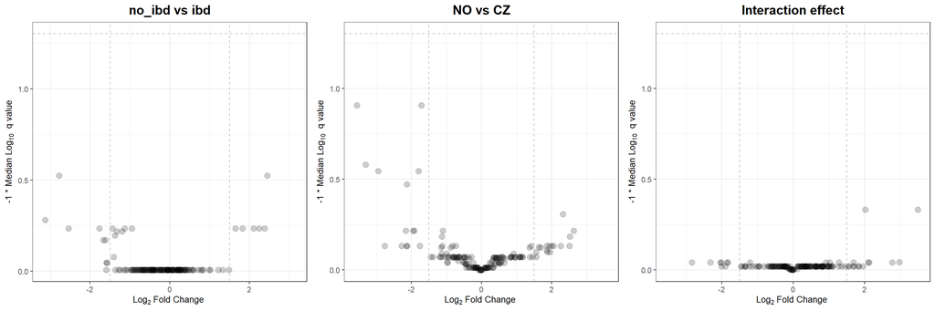

```r
# volcano plot
volcano_1 <- volcano_plot_linda(linda.output, group1,
                                taxa_table = filt_colon_uni_taxa) +
            ggtitle(paste(group,collapse=" vs "))

volcano_2  <- volcano_plot_linda(linda.output, group2,
                                taxa_table = filt_colon_uni_taxa) +
            ggtitle("NO vs CZ")

volcano_3 <- volcano_plot_linda(linda.output, group3,
                                taxa_table = filt_colon_uni_taxa) +
            ggtitle("Interaction effect")

volcano <- ggarrange(volcano_1,volcano_2,volcano_3, ncol=3)

# see the plot
volcano
```

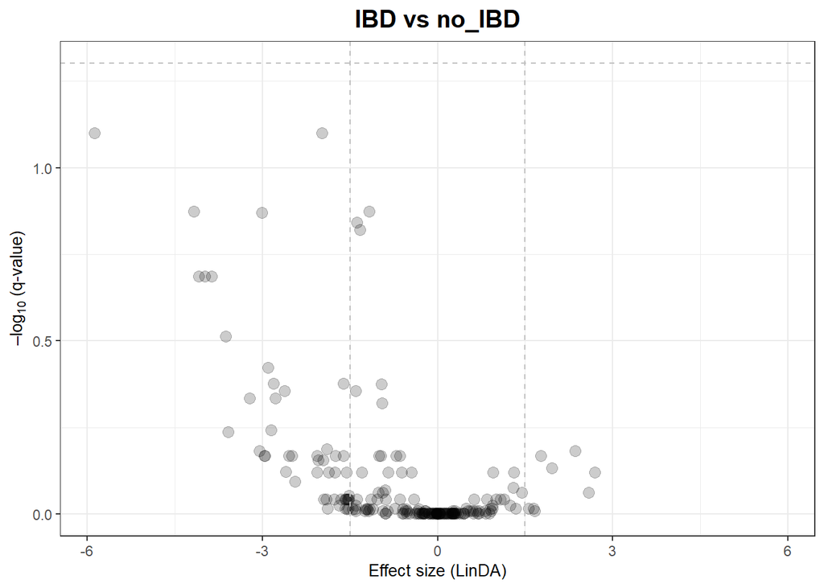

```r
volcano_linda_colon <- volcano_1 +
  ggtitle("IBD vs no_IBD") +
  xlab("Effect size (LinDA)") +
  ylab("–log"[10]~"(q-value)")

volcano_linda_ileum
```

###### 3.4.1.1.1.2 MaAsLin2

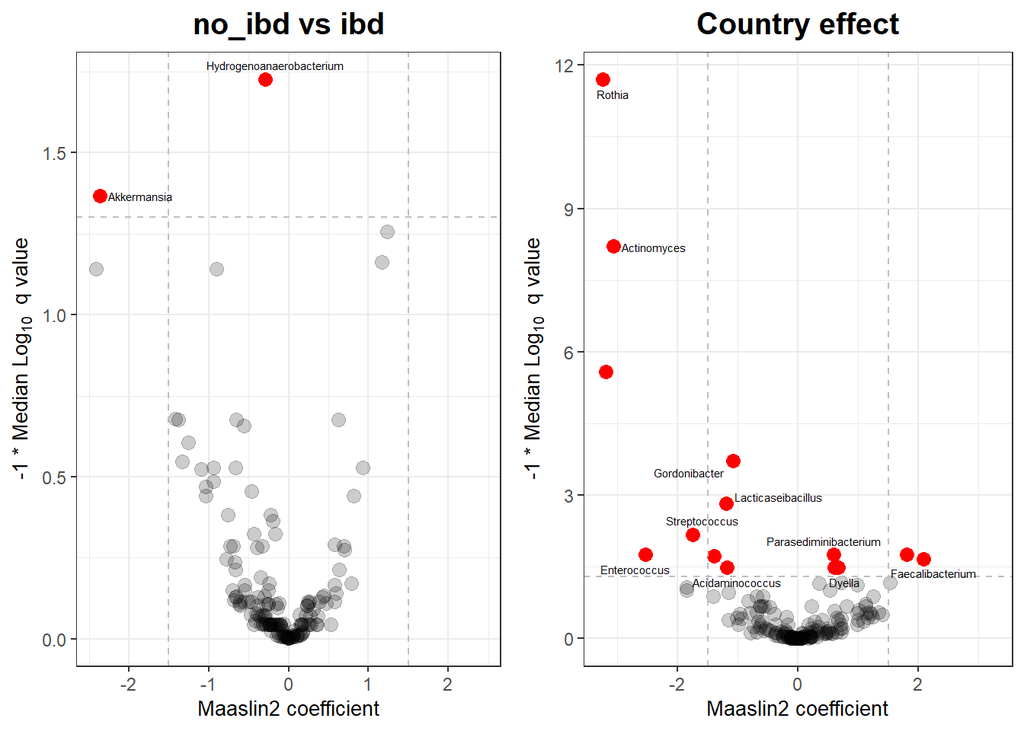

```r
volcano1 <- volcano_plot_maaslin(fit_data,filt_colon_uni_taxa) +
            ggtitle(paste(group[1], "vs", group[2]))

volcano2 <- volcano_plot_maaslin(fit_data,filt_colon_uni_taxa,variable="Country") +
            ggtitle("Country effect")

volcano <- ggarrange(volcano1,volcano2, ncol=2)
volcano
```

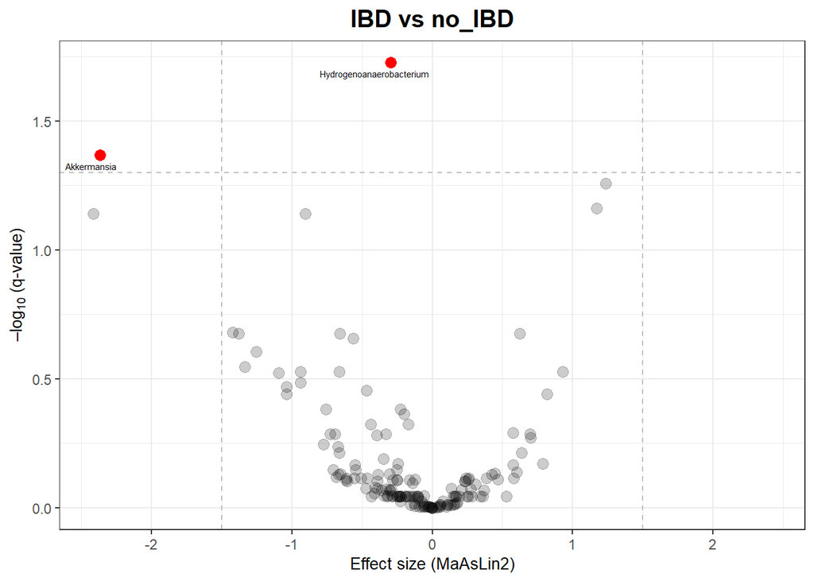

```r
volcano_maaslin_colon <- volcano1 +
  ggtitle("IBD vs no_IBD") +
  xlab("Effect size (MaAsLin2)") +
  ylab("–log"[10]~"(q-value)")

volcano_maaslin_colon
```

###### 3.4.1.1.1.3 Group - Intersection

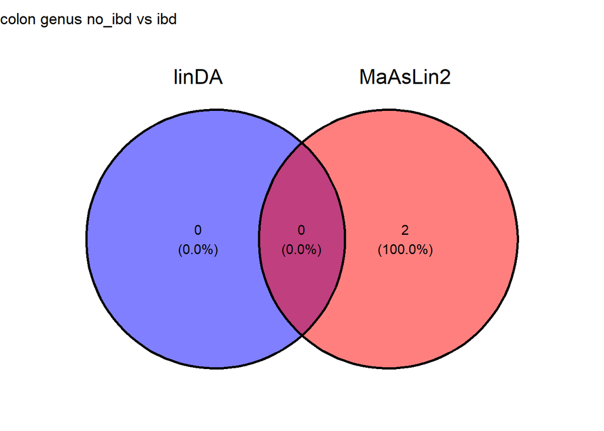

```r
intersection_results <- group_intersection(group, list_intersections, list_venns,
                                           linda.output, fit_data,
                                           raw_linda_results_genus,
                                           segment = segment,
                                           level=level)

list_intersections <- intersection_results[[1]]
list_venns <- intersection_results[[2]]
venn <- intersection_results[[3]]

# show the results
venn
```

###### 3.4.1.1.1.4 Interaction effect

```r
list_interaction_significant <- country_interaction(group,
                                                    linda.output,
                                                    list_intersections,
                                          filt_colon_uni_data,
                                          filt_colon_uni_metadata,
                                          segment=segment,
                                          level=level)

# see the result
## significant interaction effect
list_interaction_significant[[1]]
```

```r
## results for czech cohort
list_interaction_significant[[2]]
```

```
[1] NA
```

```r
## results for norwegian cohort
list_interaction_significant[[3]]
```

```
[1] NA
```

Removing problematic taxa

```r
list_intersections <- removing_interaction_problems(group,
                                                    list_interaction_significant,
                                                    list_intersections,
                                                    segment=segment,
                                                    level=level)
```

##### 3.4.1.1.2 Basic statistics

```r
uni_df <-  merge(basic_univariate_statistics(linda_data,group),
                 raw_linda_results_genus[[segment]][[group1]],
                 by="SeqID",all=TRUE)
```

```
[1] "no_ibd"
[1] "ibd"
[1] "no_ibd"
[1] "ibd"
```

```r
uni_df[["final_sig"]] <- uni_df$SeqID %in% list_intersections[[paste(segment,level,comparison_name)]][["SeqID"]]
uni_statistics[[segment]][[paste(level,comparison_name)]] <- uni_df

# for comparison
new_name <- comparison_name
addWorksheet(wb, sheetName = new_name)
writeData(wb, sheet = new_name, uni_df, rowNames=FALSE)
```

##### 3.4.1.1.3 Visualization

Heatmap visualizing the linDA’s logFoldChange for taxa with p < 0.1.

```r
list_heatmap <- list_intersections[grep(paste(segment,level),
                                  names(list_intersections),value=TRUE)]
if (length((list_heatmap[[1]][[1]]))>1){
p_heatmap_linda <- heatmap_linda(list_heatmap,colon_taxa_tab)
p_heatmap_linda
}
```

Dot heatmap

```r
if (length((list_heatmap[[1]][[1]]))>0){
dotheatmap_linda <- dot_heatmap_linda(list_heatmap,
                                      uni_statistics$terminal_ileum[grepl(level,names(uni_statistics$terminal_ileum))],
                                      colon_taxa_tab)
dotheatmap_linda
}
```

**Horizontal bar plot**

```r
if (length((list_heatmap[[1]][[1]]))>0){
p_prevalence <- horizontal_barplot(wb,taxa=levels(dotheatmap_linda$data$SeqID))

p_prevalence_final <- ggarrange(p_prevalence,
                                ggplot() + theme_minimal(),
                                nrow = 2,heights = c(1,0.085))
p <- ggarrange(dotheatmap_linda + theme(legend.position = "none"),p_prevalence_final,ncol=2,widths = c(1,0.2))
p
}
```

#### 3.4.1.2 Saving results

```r
# ALL DATA
saveWorkbook(wb,file.path(path,paste0("uni_analysis_wb_",segment,".xlsx")),
             overwrite = TRUE)

# SIGNIFICANT taxa

write.xlsx(list_intersections[grepl(segment,names(list_intersections))] %>%
            `names<-`(gsub(segment, "", names(
              list_intersections[grepl(segment,names(list_intersections))]))),
           file.path(path,paste0("significant_taxa_",segment,".xlsx")))
```

## 3.5 Results overview

#### 3.5.0.1 Alpha diversity

```r
knitr::kable(pc_observed[[segment]],
             digits = 3,
             caption = "Results of linear model testing ASV Richness")
```

Results of linear model testing ASV Richness

|  | Estimate | Std..Error | df | t.value | Pr…t.. | p.adj | sig |
| --- | --- | --- | --- | --- | --- | --- | --- |
| no_ibd vs Groupibd | 0.195 | 13.828 | 330.245 | 0.014 | 0.989 | 0.989 |  |
| no_ibd vs ibd - CZ vs NO | -0.556 | 18.199 | 238.733 | -0.031 | 0.976 | 0.976 |  |
| no_ibd vs Groupibd:CountryNO | -1.880 | 18.971 | 263.174 | -0.099 | 0.921 | 0.921 |  |

```r
knitr::kable(pc_shannon[[segment]],
             digits = 3,
             caption = "Results of linear model testing Shannon index")
```

Results of linear model testing Shannon index

|  | Estimate | Std..Error | df | t.value | Pr…t.. | p.adj | sig |
| --- | --- | --- | --- | --- | --- | --- | --- |
| no_ibd vs Groupibd | -0.038 | 0.204 | 332.621 | -0.185 | 0.854 | 0.854 |  |
| no_ibd vs ibd - CZ vs NO | -0.139 | 0.262 | 239.592 | -0.529 | 0.597 | 0.597 |  |
| no_ibd vs Groupibd:CountryNO | 0.101 | 0.275 | 262.547 | 0.367 | 0.714 | 0.714 |  |

```r
knitr::kable(pc_simpson[[segment]],
             digits = 3,
             caption = "Results of linear model testing Simpson index")
```

Results of linear model testing Simpson index

|  | Estimate | Std..Error | df | t.value | Pr…t.. | p.adj | sig |
| --- | --- | --- | --- | --- | --- | --- | --- |
| no_ibd vs Groupibd | -0.015 | 0.033 | 332.974 | -0.447 | 0.656 | 0.656 |  |
| no_ibd vs ibd - CZ vs NO | -0.036 | 0.042 | 240.107 | -0.860 | 0.391 | 0.391 |  |
| no_ibd vs Groupibd:CountryNO | 0.035 | 0.044 | 261.852 | 0.797 | 0.426 | 0.426 |  |

```r
knitr::kable(pc_pielou[[segment]],
             digits = 3,
             caption = "Results of linear model testing Pielou index")
```

Plots

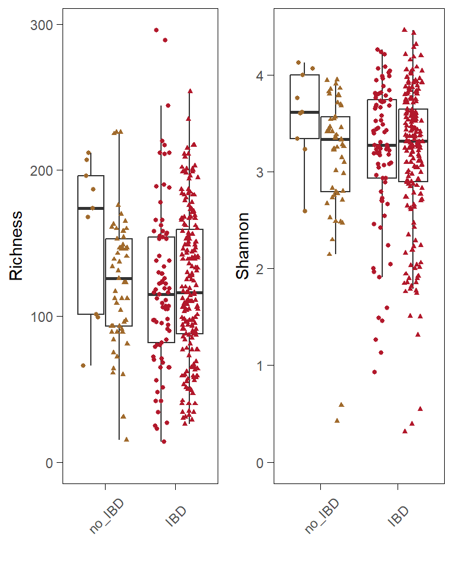

```r
alpha_div_plots[[paste(segment,"Country")]]
```

#### 3.5.0.2 Beta diversity

**Main results**

```r
knitr::kable(pairwise_aitchison_raw[[paste("genus", segment)]],
             digits = 3,
             caption = "Results of PERMANOVA - robust aitchison distance")
```

Results of PERMANOVA - robust aitchison distance

| pairs | Df | SumsOfSqs | F.Model | R2 | p.value | p.adjusted | sig |
| --- | --- | --- | --- | --- | --- | --- | --- |
| no_ibd vs ibd | 1 | 170.678 | 1.097 | 0.003 | 1.000 | 1.000 |  |
| no_ibd vs ibd , Country | 1 | 396.369 | 2.547 | 0.008 | 0.169 | 0.169 |  |
| no_ibd vs ibd : Country | 1 | 133.144 | 0.855 | 0.003 | 0.999 | 0.999 |  |

PCA

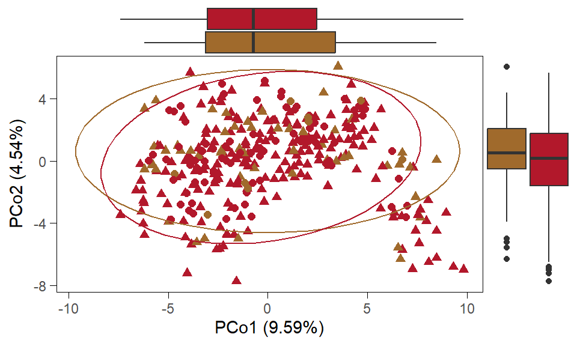

```r
pca_plots_list[[paste(segment,"genus custom")]]
```

#### 3.5.0.3 Univariate analysis

**Number of significant taxa**

```r
knitr::kable(as.data.frame(lapply(list_intersections,nrow)) %>% t() %>%
  `colnames<-`("Count") %>%
  `rownames<-`(c(names(list_intersections))),caption="Number of significant taxa")
```

Number of significant taxa

|  | Count |
| --- | --- |
| colon genus no_ibd vs ibd | 0 |

# 4 Paper-ready visualizations

**Alpha diversity**

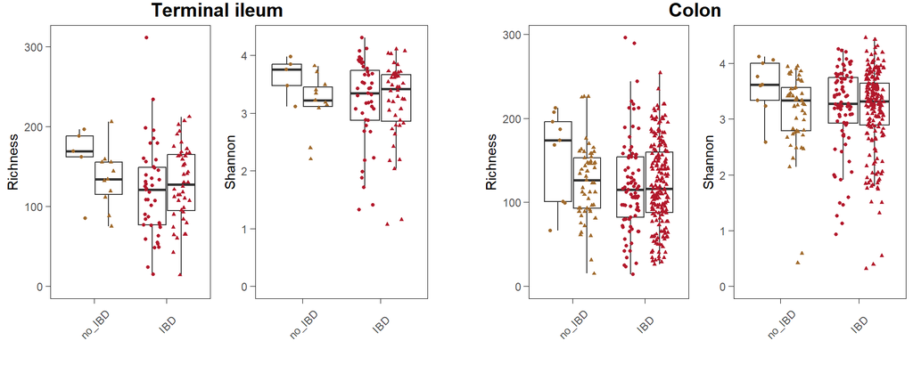

```r
p_A <- alpha_div_plots$`terminal_ileum Country` +
  ggtitle("Terminal ileum")+
  theme(plot.title = element_text(hjust=0.5,face = "bold",size = 15))

p_B <-  alpha_div_plots$`colon Country` +
  ggtitle("Colon") +
  theme(plot.title = element_text(hjust=0.5,face = "bold",size = 15))

Q3_alpha <- ggarrange(p_A,ggplot() + theme_minimal(),p_B,nrow=1, ncol=3,
                      widths = c(1,0.1,1))
Q3_alpha
```

**Beta diversity**

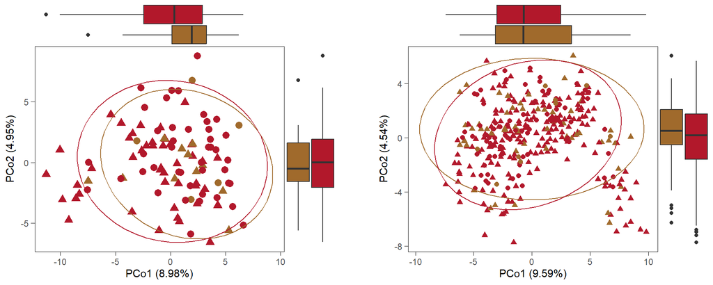

```r
pca_ti <- pca_plots_list$`terminal_ileum genus custom`
pca_colon <- pca_plots_list$`colon genus custom`

genus_Q3_beta <- ggarrange(pca_ti,
                           ggplot() + theme_minimal(),
                           pca_colon,ncol=3,
                           widths = c(1,0.1,1))
genus_Q3_beta
```

```r
save(Q3_alpha,genus_Q3_beta,file="../../../results/merged_sites/main_analysis/Q3/figures.RData")
```

**Alpha + Beta diversity**

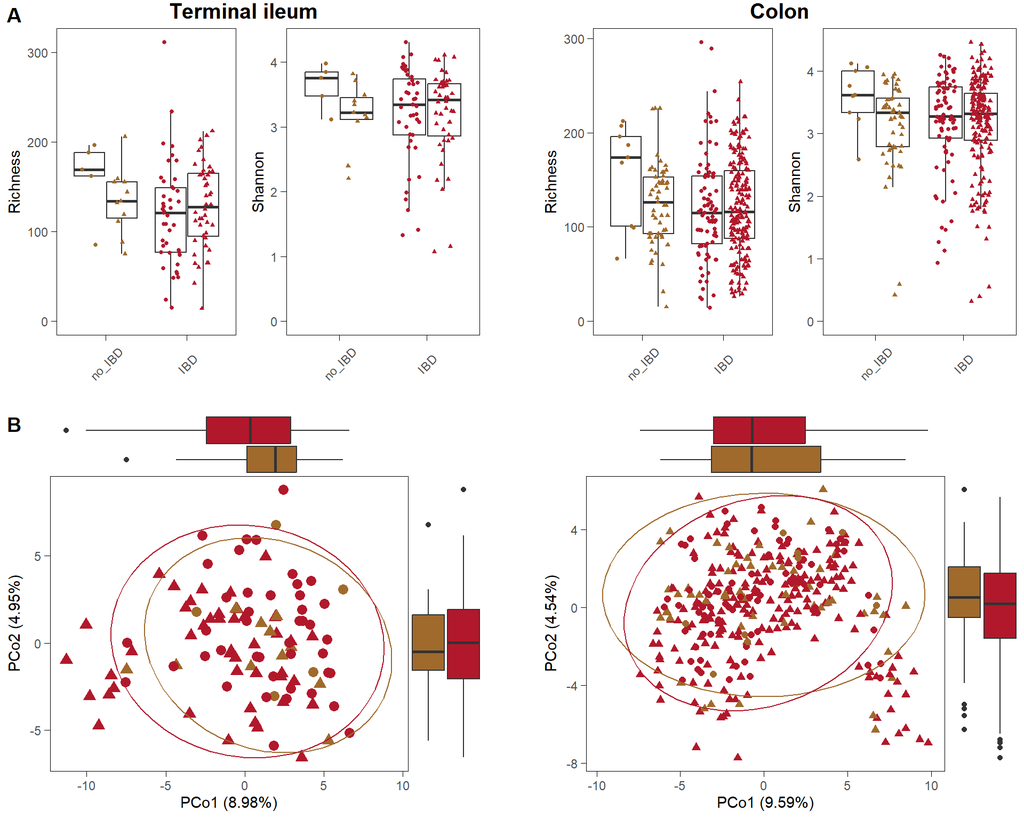

```r
alpha_beta <- ggarrange(Q3_alpha,genus_Q3_beta,
                        ncol = 1,nrow=2,labels = c("A","B"))
alpha_beta
```

## 4.1 Supplement Figure

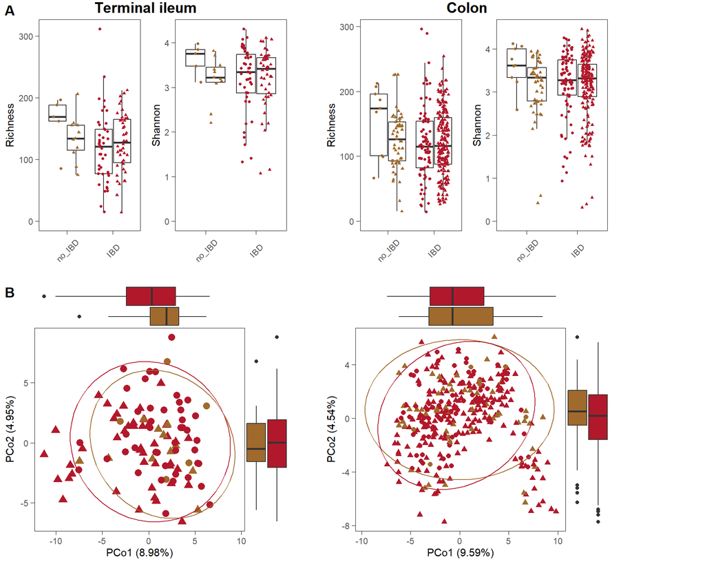

```r
alpha_beta <- ggarrange(alpha_beta,ggplot() + theme_minimal(),ncol=2,
                                widths = c(1,0.15))

alpha_beta
```

**DAA**

```r
if (exists("dot_heatmap_ileum")){
 p_ileum <- dot_heatmap_ileum +
  ggtitle("Terminal ileum") +
  theme(plot.title = element_text(hjust=0.5,face = "bold",size = 15),
        legend.position = "none")
}

if (exists("dot_heatmap_colon")){
  p_colon <- dot_heatmap_colon  +
  ggtitle("Colon") +
  theme(plot.title = element_text(hjust=0.5,face = "bold",size = 15),
        legend.position = "none")
}

if (exists("p_ileum") | exists("p_colon")){
  heatmap_plot <- ggarrange(p_ileum,
                          p_colon,
                          ncol = 2,labels=c("A","B"))
  heatmap_plot
}
```

## 4.2 Supplement Figure - Akkermansia

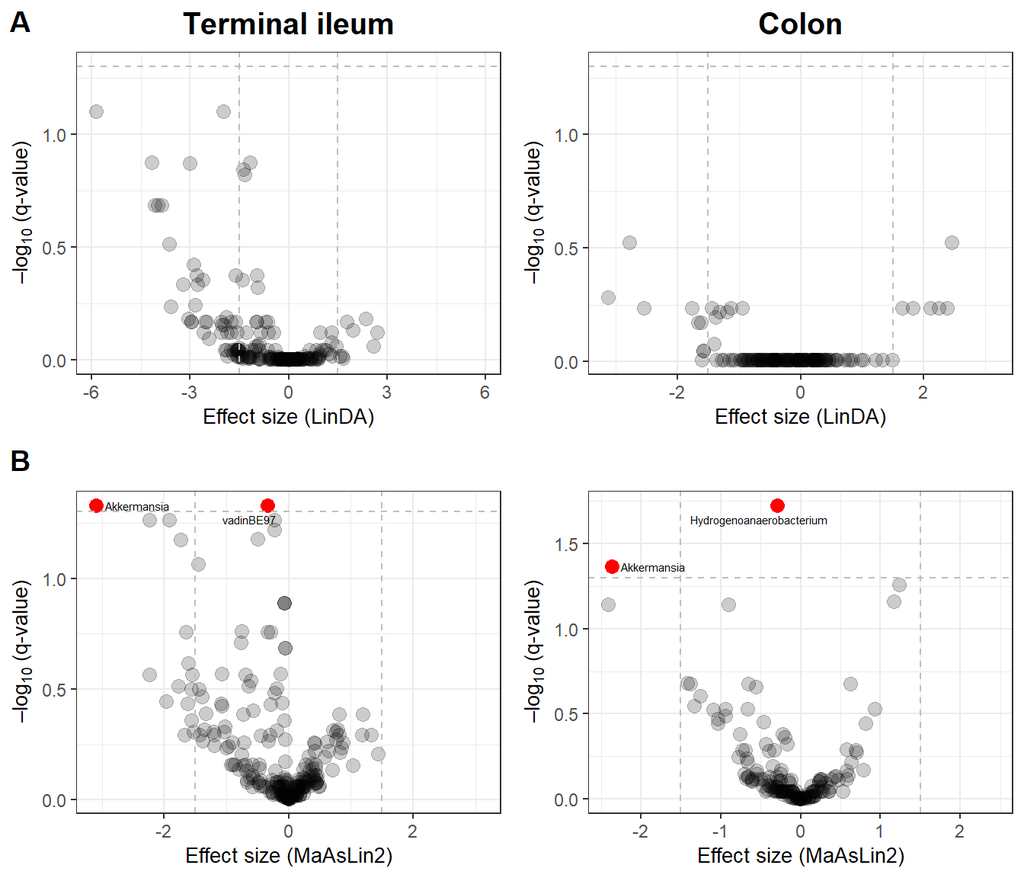

```r
volcano_figure <- ggarrange(
  volcano_linda_ileum + ggtitle("Terminal ileum"),
  volcano_linda_colon + ggtitle("Colon"),
  volcano_maaslin_ileum + ggtitle(""),
  volcano_maaslin_colon + ggtitle(""),
  labels = c("A","","B",""))

volcano_figure
```